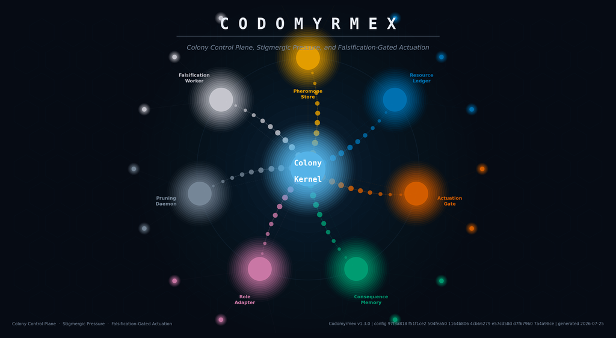

# Codomyrmex: An Artificial Ecology for Agentic Software Development

Colony Control Plane, Stigmergic Pressure, and Falsification-Gated Actuation

Daniel Ari Friedman

**Date**

July 24, 2026

**ORCID**

0000-0001-6232-9096

**DOI**

forthcoming

**Repository**

github.com/docxology/codomyrmex

**Version**

v1.3.0

# Abstract

Agentic software systems can preserve task state while still forgetting the consequences of prior actions. Codomyrmex addresses that gap with a testable control-plane claim: after a failed action, a materially similar proposal at the affected location should become measurably harder to pass through the proposal-evaluation gate. The framework records reported outcomes in consequence memory and converts them into changes in local pheromone pressure, agent trust, role labels, and resource accounting. This environmental feedback is stigmergic within a running kernel process: later agents encounter the shared field even when the model or agent identity changes. Consequence records can be made restart-persistent with file-backed SQLite; the default MCP kernel and pheromone field are process-local.

The Colony Control Plane comprises 8 cooperating subsystems for pheromone storage, resource accounting, actuation gating, consequence memory, role adaptation, pruning nomination, adversarial falsification, and lifecycle coordination. A weighted gate combines budget headroom, local hazard pressure, earned trust, and proposal completeness, subject to hard overrides; EXECUTE begins at 0.75, while new agents remain confined to the `SANDBOX` role until their recorded history satisfies the configured promotion contract. The pruning daemon nominates stale or duplicate module locations for review but does not remove them autonomously. 8 Model Context Protocol tools expose this control plane to external orchestrators without collapsing governance into execution.

Evaluation is deliberately bounded to implementation contracts and controlled fixtures. At composition time, the colony-kernel surface contains 814 passing tests with 75.5% branch coverage, 0 Ruff errors, and 0 ty diagnostics. A paired deterministic contract test shows that a failed outcome lowers the next complete proposal at the same target from EXECUTE to HOLD while leaving an unrelated target unchanged; a separate all-success fixture reaches its first non-sandbox role after 3 recorded outcomes. These results validate internal mechanics, not production safety or ecological optimality. The paper therefore pairs the implementation evidence with explicit falsification criteria, a fixed-input replay artifact, and deployment limitations. Within that bounded surface, process-local failure memory raises friction for repeated same-location proposals; external workloads, outcome attestation, and restart-persistent field storage remain necessary to establish generality. Numeric claims are injected from generated artifacts so the rendered manuscript remains tied to the evaluated code and configuration.

**Keywords:** ai-agents, model-context-protocol, mcp, multi-agent, orchestration, colony-control-plane, stigmergy, artificial-ecology, agentic-software-engineering, falsification-worker, actuation-gate, trust-scoring

*Corresponding author: Daniel Ari Friedman*

# 1 Introduction: A Bounded Control-Plane Question

Tool-using language-model agents can browse, retrieve, call APIs, edit repositories, and run software (Nakano et al. 2021; Karpas et al. 2022; Yao et al. 2023; Schick et al. 2023; Qin et al. 2023; Patil et al. 2023). Once an agent can alter persistent state, success is not only a planning problem. It is also an authorization, accounting, and feedback problem: what evidence should be inspected before an action, what should be recorded afterward, and how should that record affect the next proposal?

Long-horizon environments and software-agent benchmarks increasingly evaluate stateful, multi-step interaction rather than isolated text generation (Yang et al. 2024b, 2024a; Liu et al. 2023; Zhou et al. 2023; Xie et al. 2024; Trivedi et al. 2024). Security evaluations likewise treat tool misuse, prompt injection, privacy leakage, and trajectory-level effects as system properties (Greshake et al. 2023; Debenedetti et al. 2024; Ruan et al. 2023; Zhang et al. 2024). These results motivate explicit controls between a model’s proposal and consequential actuation.

## 1.1 Problem statement

Contemporary orchestration frameworks provide routing, checkpoints, memory, roles, and multi-agent coordination (AI 2024; Wu et al. 2023; Inc. 2024). Codomyrmex does not claim those systems lack state. It targets a narrower integration question:

> Can a recorded failure at one software location deterministically increase the admission cost of a later proposal at that same location, without changing the later model’s context or weights?

The question is deliberately local and falsifiable. A convincing positive result requires a paired case: hold agent, proposal, and budget factors fixed; add the failed outcome at one target; show that the same-target score does not increase and that an unrelated target is unchanged.

## 1.2 Bounded ecology thesis

Codomyrmex uses “colony” and “pheromone” as engineering metaphors for a shared control plane. Stigmergy describes coordination mediated through changes to a shared environment rather than direct pairwise messages (Grassé 1959; Parunak 1997; Bonabeau, Dorigo, and Theraulaz 1999). In the implementation, the shared environment is a typed, process-local signal field. `FAILURE` records caller-reported adverse outcomes, `RISK` records prospective concerns, and the gate scores their maximum at the proposal target.

The project specification’s design criterion is that the colony should become “harder to fool after every failed action.” This manuscript narrows that phrase to an implemented contract:

- a canonical failed report deposits same-target FAILURE pressure;
- effective local hazard is `max(RISK, FAILURE)`;
- higher hazard cannot increase the ordinary score;
- the paired lower-trust case moves from 0.875/EXECUTE to 0.725/HOLD;
- an unrelated target remains unchanged; and
- passive decay eventually removes the added friction.

This does not make the system deception-proof. The current MCP surface accepts caller-reported outcomes without attesting them against a prior EXECUTE authorization. The default field and consequence database are also in-memory and disappear on process restart. The verified claim is therefore process-local, report-dependent, and reversible.

## 1.3 Contribution

The paper contributes five concrete artifacts.

1. **A Colony Control Plane.** 8 named subsystems separate typed signal storage, resource accounting, actuation gating, consequence records, role inference, pruning nomination, deterministic falsification, and integration.
2. **A transparent ternary gate.** Budget, effective local hazard, trust credit, and proposal completeness form a bounded weighted score, subject to explicit hard overrides and EXECUTE/HOLD/REFUSE routing.
3. **Coupled local feedback.** Reported FAILURE and prospective RISK remain separately inspectable but jointly constrain the gate through their maximum; the integrated gate also reads recent failures from the kernel’s consequence memory.
4. **A real contract suite.** Tests use real subsystem instances to establish same-target inhibition, cross-target isolation, linear decay recovery, score bounds, trust updates, and interface behavior.
5. **A reproducible manuscript route.** Fail-closed test/lint/type evidence, generated variables, formula-derived figures, cross-reference validation, and the project renderer are orchestrated through the repository’s `run.sh` pipeline.

The contribution is a reference implementation and evidence boundary, not a completed production-security system.

The numeric values shown here are current implementation defaults or illustrative initial settings, not universal constants, fitted parameters, or empirical estimates. They are configurable and can be tuned or replaced through the corresponding runtime policy, configuration, or presentation inputs; after a change, regenerate the tests, tables, figures, and manuscript before interpreting the result. This distinction lets the implementation be reproducible without turning a reproducible fixture into a scientific calibration claim.

## 1.4 Architecture in brief

`ColonyKernel.propose_action` first runs deterministic falsification, checks the resource budget, loads the agent profile, refreshes its role label, and asks `ActuationGate` for a decision. Ordinary scoring uses

- binary budget approval (weight 0.3);
- tiered credit from effective hazard `max(RISK, FAILURE)` (weight 0.3);
- tiered trust credit, optionally reduced after 3 recent failures (weight 0.25); and
- completeness of rollback, evidence, and expected outcome fields (weight 0.15).

Budget failure, SANDBOX, trust below 0.3, and CRITICAL falsification are early returns. The higher role labels are inferred trust tiers and intended specializations; the current gate does not enforce a complete action-by-role permission matrix.

`record_outcome` is a separate caller operation. It updates the consequence store, resource ledger, trust profile, role label, and signal field. A failed test report deposits a FAST FAILURE trace; a clean report reinforces/deposits SUCCESS. Because proposal and outcome are not linked by a consumed authorization ledger, the word “outcome” in this paper means a submitted report unless explicitly qualified as attested.

The 8 MCP tools expose this stateful kernel through JSON-shaped requests and responses. A module-level singleton shares state across calls in one server process. File-backed SQLite can persist consequence records when configured, but the field has no restart-persistent backend.

## 1.5 Relation to prior work

The implementation combines ideas from several established areas without claiming to replace them:

- multi-agent systems treat autonomy, reactivity, proactivity, and social interaction as engineered properties (Wooldridge and Jennings 1995);
- computational trust and reputation update beliefs or scores from interaction history (Marsh 1994; Sabater and Sierra 2005; Kamvar, Schlosser, and Garcia-Molina 2003);
- runtime-assurance and shielding research inserts a safety decision layer between an advanced controller and actuation (Seto et al. 1998; Alshiekh et al. 2018);
- least privilege, capability security, and zero-trust architecture motivate explicit, repeatedly evaluated authority boundaries (Saltzer and Schroeder 1975; Miller and Shapiro 2003; Rose et al. 2020); and
- reproducible research, model reporting, and assurance cases motivate traceable claims and explicit limitations (Peng 2011; Mitchell et al. 2019; Raji et al. 2020; Buhl et al. 2024).

Codomyrmex’s specific combination is a target-indexed signal field coupled to a transparent software-actuation gate and consequence ledger. Comparative superiority over other frameworks is not established in this release.

## 1.6 Evidence boundary

The executed evidence is the scoped Colony Kernel quality gate and deterministic fixtures. The proposed 4-condition, 20-run benchmark has not been executed. No population refusal rate, throughput advantage, production harm reduction, or long-run convergence claim is reported. The paper treats unlinked outcome reporting, SANDBOX bootstrap, persistence, role permissions, and external calibration as open engineering work.

## 1.7 Reader’s guide

Section 2 states only the invariants supported by the runtime recurrence and gate arithmetic. Section 3 describes subsystem behavior and call sequencing. Section 4 separates the proposed external study from the live configuration. Section 5 reports executed gates, deterministic fixtures, and analytical score cases. Section 6 compares related systems and states limitations. Section 7 offers a bounded conceptual analogy rather than a formal equivalence. Section 8 documents the build and evidence chain. Section 9 summarizes the supported claim and next tests. Section 12 records design alternatives and remaining tradeoffs.

# 2 Operational Semantics and Verified Invariants

This section states the mathematical properties that follow from the checked-in implementation. It deliberately separates three kinds of statement:

1. **implementation invariants**, which follow directly from the recurrence and gate arithmetic;
2. **deterministic contract cases**, which are exercised by tests; and
3. **hypotheses**, which require external workloads or calibrated outcome data.

The gate score is a design score, not a probability of safety. The trust process is a bounded accounting rule, not a Bayesian posterior. No claim below establishes production safety, optimality, differential privacy, or long-run ecological convergence.

The numeric values shown here are current implementation defaults or illustrative initial settings, not universal constants, fitted parameters, or empirical estimates. They are configurable and can be tuned or replaced through the corresponding runtime policy, configuration, or presentation inputs; after a change, regenerate the tests, tables, figures, and manuscript before interpreting the result. The equations in this section state consequences of the current implementation; they are not a claim that the selected constants are universal or empirically calibrated.

## 2.1 Capped local signal field

Let $J_t \subseteq \mathcal L \times \mathcal K$ be the finite set of compound location–signal keys present at tick $t$, where $\mathcal K$ contains `FAILURE`, `SUCCESS`, `RISK`, `NEED`, `DEPENDENCY`, and `HUMAN_PRIORITY`. For a fixed finite key set $J$, the field state is

$$x_t \in [0.0,M]^J,\qquad M=10.0 .
\qquad{(1)}$$

This capped non-negative cube is a complete metric lattice under the supremum metric. It is not a vector space: negative scaling and unrestricted addition leave the state space.

For key $j$, let $\epsilon_j>0$ be its fixed per-tick evaporation amount and let $d_{j,t}\geq 0$ be the effective deposits applied during step $t$, after source and trust multipliers. With the convention “evaporate, then deposit,” the implemented update can be represented as

$$x_{j,t+1}
=
\min\!\left(M,\,
\max(0.0,x_{j,t}-\epsilon_j)+d_{j,t}
\right).
\qquad{(2)}$$

The 3 configured evaporation amounts are $\epsilon_{\mathrm{FAST}}=0.3$, $\epsilon_{\mathrm{NORMAL}}=0.1$, and $\epsilon_{\mathrm{SLOW}}=0.02$ strength units per tick. A caller may deposit at another point in the scheduler cycle, so exact within-tick values depend on operation order; the range and monotonicity results below do not.

**Lemma 1 (range invariance).** If $x_{j,0}\in[0.0,M]$, then $x_{j,t}\in[0.0,M]$ for every finite sequence of non-negative deposits.

*Proof.* The inner maximum is non-negative and the outer minimum is at most $M$. Induction over $t$ completes the argument. $\square$

**Lemma 2 (passive linear decay).** With no deposits for $n$ ticks,

$$x_{j,t+n}=\max(0.0,x_{j,t}-n\epsilon_j).
\qquad{(3)}$$

*Proof.* Apply the subtract-and-floor operation repeatedly. Before the first floor event, exactly $\epsilon_j$ is removed per tick; after the value reaches zero, further applications leave it at zero. $\square$

A trace with initial strength $s$ therefore disappears after at most

$$N_{\mathrm{extinct}}(s,\epsilon_j)=
\left\lceil \frac{s}{\epsilon_j}\right\rceil
\qquad{(4)}$$

ticks without reinforcement. This is finite forgetting, not exponential half-life. For a unit trace, FAST, NORMAL, and SLOW disappear after 4, 10, and 50 discrete ticks, respectively (the ceiling matters when $s/\epsilon_j$ is not integral).

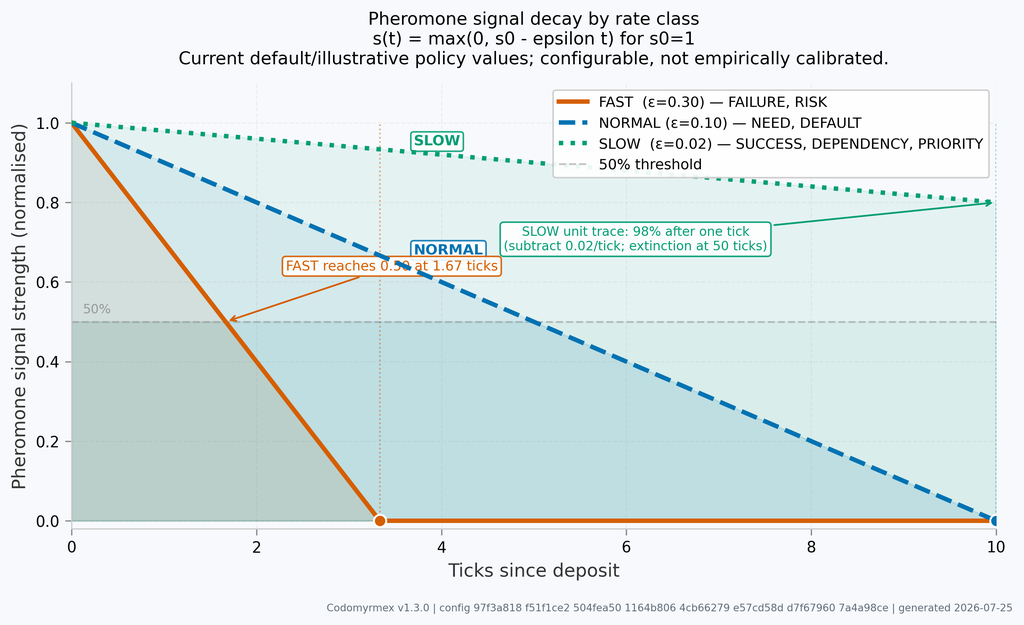

Figure 1: Analytical trajectories of a 1.0-strength trace under the implemented subtractive decay rule. Each curve is s(t)=max(0.0,s0-epsilon t), with no deposits, reads, or reinforcement. Vertical markers show continuous extinction points; the runtime updates at integer ticks and removes values at or below zero. Current default/illustrative policy values; configurable, not empirically calibrated. Parameters are generated from the manuscript snapshot.

## 2.2 From reported failure to local gate pressure

The witness retains prospective `RISK` and caller-reported `FAILURE` as separate channels. The gate uses their maximum as effective local hazard pressure:

$$h_t(\ell)=
\max\!\left(
x_t(\ell,\mathrm{RISK}),
x_t(\ell,\mathrm{FAILURE})
\right).
\qquad{(5)}$$

The risk-clearance component is the piecewise function

$$r(h)=
\begin{cases}
1.0, & 0.0\leq h<3.0,\\
0.5, & 3.0\leq h<6.0,\\
0.0, & h\geq 6.0.
\end{cases}
\qquad{(6)}$$

**Proposition 1 (local monotonicity).** Holding all other gate inputs fixed, increasing either `RISK` or `FAILURE` pressure at the proposal target cannot increase the gate score.

*Proof.* The maximum in Equation 5 is coordinate-wise non-decreasing, while $r(h)$ in Equation 6 is non-increasing. Its gate coefficient is positive. $\square$

**Deterministic paired case.** A caller-reported failed outcome deposits a base-strength 2.0 `FAILURE` signal from source `TEST`. The source multiplier 1.5 produces effective pressure 3.000. For an authorized lower-tier agent with a complete proposal, clear budget, and no prior pressure, the ordinary score changes from

$$g_{\mathrm{clear}}=0.3+0.3+0.25(0.5)+0.15=0.875
\qquad{(7)}$$

to

$$g_{\mathrm{failed}}=0.3+0.3(0.5)+0.25(0.5)+0.15=0.725 .
\qquad{(8)}$$

Thus the same-target decision changes from EXECUTE to HOLD, while an otherwise identical proposal at another target remains at 0.875. A real integration test checks all three claims. Passive decay eventually restores the clear-field score. This is the precise implemented meaning of “harder to pass after local failure”; it is neither permanent nor a proof that deception is prevented.

## 2.3 Gate arithmetic and hard overrides

For proposals that reach ordinary scoring,

$$g=0.3b+0.3r+0.25u+0.15c,
\qquad{(9)}$$

where $b\in\{0.0,1.0\}$, $r\in\{0.0,0.5,1.0\}$, $u$ uses the generated trust-credit tiers and optional 0.25 recent-failure penalty, and $c$ is generated from zero through 3 missing fields with a 0.35 penalty per field.

Four checks can bypass ordinary thresholding:

- an unaffordable proposal returns HOLD in the integrated kernel and REFUSE in standalone gate use;
- `SANDBOX` returns REFUSE;
- trust below 0.3 returns REFUSE; and
- a CRITICAL falsification finding returns REFUSE.

Otherwise $g\geq0.75$ yields EXECUTE, $0.5\leq g<0.75$ yields HOLD, and $g<0.5$ yields REFUSE.

**Theorem 1 (score boundedness).** Every ordinary score is in $[0.0,1.0]$.

*Proof.* Every component is in $[0.0,1.0]$, every coefficient is non-negative, and the coefficients sum to 1.0. The implementation additionally clips the sum to $[0.0,1.0]$. $\square$

**Proposition 2 (component monotonicity).** On the ordinary path, improving budget approval, risk clearance, trust credit, or completeness while holding the other components fixed cannot reduce $g$. Increasing local hazard or activating the recent-failure penalty cannot increase $g$.

These are arithmetic monotonicity statements. They do not imply that $g$ is calibrated to real-world harm. Such calibration would require linked proposals, independently attested outcomes, representative workloads, and held-out evaluation.

Figure 2 visualizes the exact score tiers and the continuous completeness envelope used only to make the discontinuities legible.

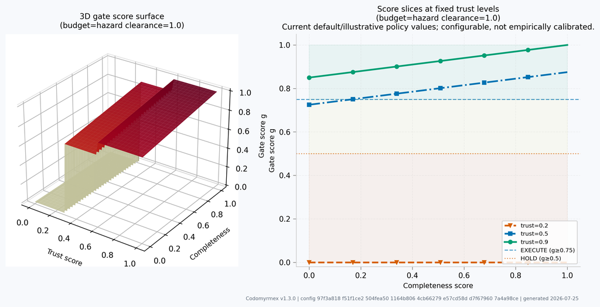

Figure 2: Analytical gate-score surface with budget and local hazard clearance fixed at 1.0. The implementation’s trust hard floor and trust-credit tiers are shown; completeness is plotted continuously as a visual envelope even though runtime completeness is discrete. Threshold planes identify the configured HOLD and EXECUTE boundaries. This is formula-derived, not an empirical risk surface. Current default/illustrative policy values; configurable, not empirically calibrated.

### 2.3.1 What HOLD can and cannot establish

A third decision can be useful when revision supplies information, but it does not automatically dominate a binary gate. Let $L_E(z)$ and $L_R(z)$ be expected losses from EXECUTE and REFUSE at observed state $z$. Let $C_H$ be revision cost and let $Z'$ be the evidence available after revision. HOLD has lower expected loss only when

$$C_H+\mathbb E\!\left[\min\{L_E(Z'),L_R(Z')\}\mid z\right]
<
\min\{L_E(z),L_R(z)\}.
\qquad{(10)}$$

The current implementation returns actionable evidence requests, but it does not estimate any term in Equation 10. HOLD is therefore an auditable design choice and a future empirical hypothesis, not a proved optimum.

## 2.4 Trust as bounded evidence accounting

For recorded outcome $n$, trust follows

$$\tau_{n+1}=\operatorname{clip}_{[0.0,1.0]}(\tau_n+\Delta_n),
\qquad{(11)}$$

with

$$\Delta_n=
\begin{cases}
+0.04, & \text{tests pass},\\
-0.08, & \text{tests fail}
\end{cases}
-0.05\,\mathbf 1_{\mathrm{repair}}
+0.03h_n,\qquad h_n\in[-1.0,1.0].
\qquad{(12)}$$

This proves boundedness by construction. It does not prove convergence. With continuing random non-zero increments, a clipped constant-step process can continue moving indefinitely.

If tests pass independently with probability $p$, with no repairs and neutral human feedback, the expected *unclipped* increment is

$$\mathbb E[\Delta]=0.04p+-0.08(1-p).
\qquad{(13)}$$

The drift is zero at $p=0.667$, positive above it, and negative below it. This is a balance point for expected increments—not a unique trust equilibrium—because the update contains no state-dependent restoring term.

Starting from $\tau_0=0.1$, an all-success path adds 0.04 per outcome until clipping. The first 3 recorded successes satisfy the generated promotion contract for `REPAIR_ANT`. This is a deterministic path claim, not an expected hitting time for an imperfect agent. Moreover, the current MCP surface accepts caller-reported outcomes without linking them to a prior EXECUTE decision; the three-record bootstrap must therefore be treated as supervised evidence, not autonomous proof of competence.

The integrated gate now holds a reference to the same `ConsequenceMemory` used by the kernel. 3 recent failures reduce trust credit by 0.25 before weighting. This wiring property and its score effect are contract-tested.

## 2.5 Privacy and integrity boundary

The released mechanism is deterministic and does not provide differential privacy. Under replacement adjacency, one record can change a trust increment from its maximum $+0.07$ to its minimum $-0.16$, so the one-step global sensitivity is at most

$$\Delta_{\mathrm{replace}}=0.23 .
\qquad{(14)}$$

Clipping may reduce the realized difference near a boundary but does not lower this global bound. Any future noisy release would also need an explicit adjacency relation, composition accounting across repeated queries, and a utility analysis (Dwork and Roth 2014).

The more immediate integrity issue is attestation: `colony_record_outcome` currently constructs a proposal from caller input and does not require an outstanding, matching, previously EXECUTEd proposal identifier. Trust and local pressure therefore express *recorded reports*, not independently verified ground truth. This limitation bounds every causal and security claim in the manuscript.

## 2.6 Verified claims and open hypotheses

Table **¿tbl:formal-claim-status?** separates proved implementation properties, deterministic contract cases, open empirical hypotheses, and claims that are false for this release.

Epistemic status of the formal claims. {#tbl:formal-claim-status}

| Statement | Status | Evidence required |
| --- | --- | --- |
| Field values remain in $[0,10.0]$ | Proved implementation invariant | Recurrence and saturation tests |
| A passive trace decays linearly and disappears in finite ticks | Proved implementation invariant | Exact tick tests |
| More same-target RISK or FAILURE pressure cannot increase the ordinary score | Proved arithmetic invariant | Monotonicity and paired integration tests |
| One canonical failed outcome moves the paired lower-tier case from 0.875/EXECUTE to 0.725/HOLD | Verified deterministic case | Real subsystem integration test |
| Gate score lies in $[0.0,1.0]$ | Proved arithmetic invariant | Component ranges and clip |
| Trust lies in $[0.0,1.0]$ | Proved implementation invariant | Clipped update |
| The gate lowers production harm | Open empirical hypothesis | Linked, attested, representative trials |
| HOLD improves decisions | Open value-of-information hypothesis | Revision-cost and outcome study |
| The ecology converges or is optimal | Not established | A specified stochastic model and external validation |
| Published trust is differentially private | False for the current release | A randomized mechanism and privacy accounting |

The result is intentionally narrower than an abstract theory of agent societies. It is a checkable contract for this implementation and a map of what must be measured before stronger claims are warranted.

# 3 Implementation Method and Control-Plane Semantics

## 3.1 Colony Kernel Architecture

### 3.1.1 Overview of the 8 Subsystems

The Colony Control Plane is realised as a single Python package (`codomyrmex.colony_kernel`) with shared value objects and enumerations in `models.py`, canonical subsystem implementations in standalone modules, and the `ColonyKernel` integration class orchestrating their lifecycle. The design keeps communication explicit: subsystems exchange typed models, while the kernel owns cross-subsystem sequencing and state transitions.

Table **¿tbl:subsystem_overview?** enumerates the 8 subsystem roles used by the control plane.

Colony Control Plane subsystem overview. {#tbl:subsystem_overview}

| Subsystem | Primary Module | Responsibility |
| --- | --- | --- |
| **PheromoneStore** | `pheromone_store.py` | Stores typed location signals; deposits, queries, reinforces, and subtractively decays traces. |
| **ResourceLedger** | `resource_ledger.py` | Checks and consumes 7-dimensional, period-scoped resource budgets. |
| **ActuationGate** | `actuation_gate.py` | Combines budget approval, effective local hazard, trust, and completeness into EXECUTE / HOLD / REFUSE. |
| **ConsequenceMemory** | `consequence_memory.py` | Stores reported outcomes and profiles; computes trust deltas and recent-failure counts. Default storage is in memory. |
| **RoleAdapter** | `role_adapter.py` | Infers role labels from trust and proposal count; only SANDBOX has role-specific gate behavior. |
| **PruningDaemon** | `pruning_daemon.py` | Nominates stale or duplicate modules; mutation is a separate explicit API. |
| **FalsificationWorker** | `falsification/` | Runs 11 deterministic checks across 10 attack-vector categories and deposits finding signals. |
| **ColonyKernel** | `kernel.py` | Owns subsystem instances and sequences the high-level proposal, outcome, status, pruning, and tick APIs. |

Unless a table or experiment explicitly says otherwise, the numeric weights, thresholds, decay settings, and effort profiles described below are current implementation defaults and example/initial values. They are configurable policy parameters, not calibrated universal constants; tuning them requires rerunning the focused contract tests and regenerating the dependent evidence bundle.

The integration entry point is `ColonyKernel`, instantiated once by the default MCP adapter. Its high-level methods coordinate the components, while lower-level classes remain importable for standalone use and testing.

Figure 3 illustrates the control-plane topology: `ColonyKernel` at the centre, each of the 7 operational subsystem classes at the leaves, all sharing the `models.py` value-object contract.

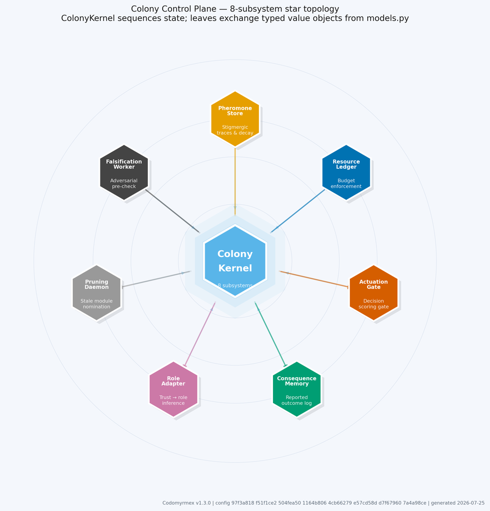

Figure 3: Colony Control Plane topology. ColonyKernel owns subsystem lifecycle and sequencing; the live integration object supplies the operational leaf-node count, and the nodes exchange typed value objects from the shared models.py contract. Coloured by functional role; the diagram shows ownership and information flow, not deployment topology or performance.

## 3.2 Pheromone Gradients (PheromoneStore)

The `PheromoneStore` encapsulates process-local environmental memory in the tradition of stigmergic coordination (Grassé 1959; Dorigo and Stützle 2004). Rather than requiring direct agent-to-agent messages, the running kernel writes typed traces into a shared in-memory `TraceField` and reads them during gate evaluation. Unreinforced traces lose a fixed amount per tick and are removed at zero. This is an engineering analogy to stigmergy, not a claim that the store implements biological chemistry or variational free-energy minimisation.

**Signal types.** The store recognises 6 signal types (`SignalType` enum), each with distinct ecological meaning:

Table **¿tbl:signal_types?** lists the signal classes and their effect on the gate.

Pheromone signal types and gate effects. {#tbl:signal_types}

| Signal Type | Ecological Analogue | Decay Class | Effect on Gate |
| --- | --- | --- | --- |
| `FAILURE` | Trail avoidance pheromone | `FAST` | Records failed outcome reports; the gate scores the maximum of local FAILURE and RISK pressure. |
| `SUCCESS` | Trail amplification pheromone | `SLOW` | Reinforced on passing outcomes and retained as positive local history; it does not reduce `risk_ok` directly. |
| `RISK` | Caution marker | `FAST` | Prospective concern channel; combined with FAILURE through a maximum when computing local hazard pressure. |
| `NEED` | Resource request | `NORMAL` | Broadcast by agents requiring attention at a location; does not feed gate pressure directly. |
| `DEPENDENCY` | Usage trace | `SLOW` | Deposited by `record_outcome` to signal active module consumption; a strength ≥ 2.0 vetoes `PruningDaemon` nomination. |
| `HUMAN_PRIORITY` | Operator-injected signal | `SLOW` | Receives the HUMAN source multiplier and remains visible to diagnostics; it is not a gate override. |

**Decay rates.** Each signal is assigned one of 3 `DecayRate` classes. The enum value is a multiplier $m_k$ applied to the base subtraction $\epsilon_0=0.1$ strength units per tick. The runtime update is linear and floored at zero, as formalized in Equation 2.

Table **¿tbl:methodology_decay_rates?** records unit-trace behavior for each decay class.

Subtractive pheromone decay classes for a unit-strength trace. {#tbl:methodology_decay_rates}

| Class | Multiplier $m_k$ | Subtraction $\epsilon_0m_k$ | Unit trace after one tick | Unit-trace extinction |  |
| --- | --- | --- | --- | --- | --- |
| `FAST` | 3.0 | 0.3/tick | 70% | 4 discrete ticks |  |
| `NORMAL` | 1.0 | 0.1/tick | 90% | 10 discrete ticks |  |
| `SLOW` | 0.2 | 0.02/tick | 98% | 50 discrete ticks |  |

Extinction scales with deposited strength and reinforcement. The table therefore does not assign a universal half-life to a class; it gives a reproducible unit-trace example. FAST warnings clear quickly, while SLOW success, dependency, and priority traces retain more history.

**Trust multipliers by source.** Not all sources carry equal epistemic weight. The `PheromoneStore` scales a signal’s effective initial strength by the depositing source’s trust multiplier before writing to the `TraceField`:

The effective-strength calculation in Equation 15 determines the initial trace written to the field.

$$\text{effective\_strength} = \text{signal.strength} \times \text{source\_multiplier} \times \text{trust\_factor}\qquad{(15)}$$

where `source_multiplier` is HUMAN×2.0, TEST×1.5, SECURITY×1.5, AGENT×1.0, or RUNTIME×1.0. The optional `trust_factor` is supplied only on selected kernel deposits; many runtime and test deposits use its neutral default.

**Compound key addressing.** Each pheromone occupies a unique position in the `TraceField` identified by the compound key `"{location}:{signal_type.value}"`. This allows FAILURE and SUCCESS signals at the same module path to be tracked and decayed independently, preserving the sign and type of the colony’s accumulated evidence.

The generated unit-trace trajectories and their assumptions appear in Figure 1.

## 3.3 Resource Budget (ResourceLedger)

The `ResourceLedger` enforces a multi-dimensional budget envelope over the colony’s resource consumption (Bonabeau, Dorigo, and Theraulaz 1999). Rather than tracking a single scalar cost, it maintains 7 independent dimensions of `ResourceCost`:

Table **¿tbl:resource_dimensions?** lists the dimensions enforced by the ledger.

Resource budget dimensions enforced by `ResourceLedger`. {#tbl:resource_dimensions}

| Dimension | Type | Description |
| --- | --- | --- |
| `llm_calls` | `int` | Number of LLM API invocations. |
| `runtime_seconds` | `float` | Wall-clock execution time. |
| `risk_level` | `float ∈ [0.0,1.0]` | Aggregate risk fraction of the action. |
| `human_attention_minutes` | `float` | Estimated operator review time. |
| `merge_risk` | `float ∈ [0.0,1.0]` | Probability of merge conflicts or integration failures. |
| `doc_debt` | `float` | Documentation gap accumulation score. |
| `security_exposure` | `float ∈ [0.0,1.0]` | Estimated security surface increase. |

The ledger’s `can_afford` method returns an `(approved, reason)` pair after checking whether the proposed estimate, added to usage in the current reset period, would breach any dimension. A false approval bypasses ordinary scoring (`gate_score = 0.0`) because budget failure is an early return rather than a score penalty. The final decision depends on the calling mode. In standalone mode, `ActuationGate.evaluate(proposal, profile)` performs the ledger check and returns `REFUSE`; in integrated mode, `ColonyKernel` supplies `budget_approved=False` and the gate returns `HOLD` so a caller may retry after the period resets. On a submitted outcome report, `consume` uses `outcome["cost"]` when it is a valid resource-cost mapping and otherwise falls back to the proposal estimate. The accumulator resets when elapsed time crosses the configured `period_seconds`; this is a fixed-period reset from the last start or reset, not a continuously sliding window.

## 3.4 Actuation Gate

The actuation gate is the colony’s central advisory decision layer: it aggregates signals from the resource ledger, pheromone field, agent trust store, and proposal completeness into a scalar gate score, then routes that score to one of 3 decisions.

**Parameter status.** The numeric values shown here are current implementation defaults or illustrative initial settings, not universal constants, fitted parameters, or empirical estimates. They are configurable and can be tuned or replaced through the corresponding runtime policy, configuration, or presentation inputs; after a change, regenerate the tests, tables, figures, and manuscript before interpreting the result. In particular, the weights, thresholds, trust deltas, decay amounts, and presentation ranges below describe the current release snapshot. “Configured” therefore means “declared by the current runtime/configuration contract,” not “validated as optimal for every deployment.” The numerical details in this subsection are example/initial values that can be tuned through their owning runtime or presentation configuration. Any tuning should rerun the contract suite and regenerate the dependent tables, figures, captions, and provenance before a new interpretation is made.

### 3.4.1 Gate Scoring Formula

The gate score $g$ is a weighted linear combination of 4 normalised components (Equation 16):

$$g = 0.3 \cdot \text{budget\_ok} + 0.3 \cdot \text{risk\_ok} + 0.25 \cdot \text{trust\_ok} + 0.15 \cdot \text{completeness}\qquad{(16)}$$

clamped to $[0.0, 1.0]$ after summation: $g \leftarrow \max(0.0,\; \min(1.0,\; g))$.

The weights sum to 1.0. Each component is described below.

**`budget_ok`** ($w = 0.3$) is binary resource headroom. A false approval bypasses ordinary scoring; each proposal receives a fresh pre-check.

**`risk_ok`** ($w = 0.3$): The gate senses both RISK and FAILURE at the proposal target and defines effective local hazard as their maximum. It maps that pressure through two module-level constants:

Table **¿tbl:risk_pressure_mapping?** defines the discrete mapping from effective local hazard pressure to the normalised score component.

Local hazard-pressure mapping used by the gate. {#tbl:risk_pressure_mapping}

| `max(RISK, FAILURE)` pressure | `risk_ok` |
| --- | --- |
| $\geq 6.0$ (`_HIGH_RISK_THRESHOLD`) | 0.0 |
| $\geq 3.0$ (`_MEDIUM_RISK_THRESHOLD`) | 0.5 |
| $< 3.0$ | 1.0 |

A location accumulating either prospective RISK findings or reported failed outcomes can therefore lose risk credit until the relevant trace decays. SUCCESS is retained as a separate diagnostic channel and does not cancel the maximum.

**`trust_ok`** ($w = 0.25$): Agent trust score normalised to gate range. The gate reads `AgentTrustProfile.trust_score` and maps it as follows:

Table **¿tbl:trust_mapping?** gives the hard floor and two scoring tiers for trust.

Trust-score mapping used by the actuation gate. {#tbl:trust_mapping}

| `trust_score` | `trust_ok` |
| --- | --- |
| $\geq 0.6$ | 1.0 |
| $0.3 \leq \text{trust\_score} < 0.6$ | 0.5 |
| $< 0.3$ | hard REFUSE (early return, `gate_score = 0.0`) |

A new agent starts at `trust_score = 0.1`; profiles between the hard floor and full-credit threshold receive 0.5 trust credit.

**Trust penalty.** When `ConsequenceMemory` is available and the agent’s recent-failure count reaches 3, the gate applies:

$$\text{trust\_ok} \leftarrow \max(0.0,\; \text{trust\_ok} - 0.25)\qquad{(17)}$$

This decrement reduces `trust_ok` — the gate’s normalised trust contribution for this evaluation only. It does not modify the agent’s persistent `trust_score` stored in `ConsequenceMemory`. The agent’s durable trust record is updated separately on each `record_outcome` call; the gate penalty is a single-evaluation correction that makes the gate more conservative while an agent is on a losing streak, without permanently penalising the agent’s history.

**`completeness`** ($w = 0.15$): Evidence mass of the proposal. The gate inspects 3 fields: `rollback_plan`, `evidence`, and `expected_outcome`.

The proposal-completeness expression in Equation 18 supplies the ordinary score component for incomplete proposals.

$$\text{completeness} = \max(0.0,\; 1.0 - |\text{missing}| \times 0.35)\qquad{(18)}$$

The rendered result tables compute all discrete completeness values from that expression.

### 3.4.2 Decision Thresholds

The gate maps the numeric score to a ternary verdict:

Table **¿tbl:gate_decision_thresholds?** gives the three threshold bands.

Actuation-gate decision thresholds. {#tbl:gate_decision_thresholds}

| Score Range | Decision | Effect |
| --- | --- | --- |
| $g \geq 0.75$ | **EXECUTE** | Advisory approval returned; the kernel does not perform or enforce the action. |
| $0.5 \leq g < 0.75$ | **HOLD** | Revision or recovery evidence returned; the kernel does not maintain a requeue. |
| $g < 0.5$ | **REFUSE** | Refusal returned and, in the integrated path, FAILURE pressure deposited at the target. |

### 3.4.3 Hard Overrides

Four safety conditions bypass the numeric score entirely, evaluated in order before gate scoring begins:

1. **Budget failure.** A `False` return from `ResourceLedger.can_afford` causes an immediate hard override with `gate_score = 0.0`. Standalone gate evaluation returns `REFUSE`; kernel/caller-supplied budget failure returns `HOLD` for requeue after the budget period resets. No further evaluation occurs.
2. **SANDBOX role.** Agents with role `SANDBOX` always receive REFUSE regardless of trust score, pheromone state, or proposal quality. The entry label is held until at least 3 proposals and the live promotion threshold are satisfied.
3. **Trust floor.** A `trust_score < 0.3` triggers an early REFUSE with `gate_score = 0.0`.
4. **Critical falsification.** Any `CRITICAL` finding from the `FalsificationWorker` triggers an immediate REFUSE with the finding’s remediation attached to `GateResult.required_evidence`.

### 3.4.4 Generated policy cases

Table **¿tbl:representative-gates?** in Section 5 is generated from the live weights, thresholds, tier mappings, and missing-field penalty. This avoids maintaining a second, hand-calculated worked example in prose.

## 3.5 Consequence Memory (SQLite-backed)

The `ConsequenceMemory` subsystem stores each reported `ConsequenceRecord` and the derived agent profile. It uses SQLite WAL mode when configured with a file path. The kernel and MCP defaults use `:memory:`, so records survive only for the process lifetime unless an operator supplies a persistent database path. Because the MCP outcome endpoint does not yet attest reports against a prior EXECUTE record, this is an audit log of submitted outcomes rather than independent ground truth.

The schema comprises three tables: `consequences` (one row per submitted consequence report), `agent_profiles` (one row per agent, containing current trust state and role), and `consequence_history` (a chronological sequence of consequence IDs per agent, capped at the most recent 200 rows).

**Trust delta computation.** When a `ConsequenceRecord` is persisted with `trust_delta == 0.0`, the memory computes it from outcome fields:

The durable trust update is computed by Equation 19.

$$\Delta_\text{trust} = \Delta_\text{pass/fail} + \Delta_\text{repair} + h \cdot \Delta_\text{human}\qquad{(19)}$$

where $\Delta_\text{pass/fail} = 0.04$ if tests passed else $-0.08$; $\Delta_\text{repair} = -0.05$ if repair was needed; $h \in [-1.0, 1.0]$ is the parsed human feedback score and $\Delta_\text{human} = 0.03$. The delta is clamped to keep `trust_score` within $[0.0,1.0]$.

**`recent_failures()` and gate coupling.** The `ConsequenceMemory` exposes a `recent_failures(agent_id, window=10)` method that the `ActuationGate` queries when a consequence-memory reference is provided. When failed reports among the agent’s 10 most recent consequence records reach 3 or more, the gate applies an additional $-0.25$ decrement to `trust_ok`—the normalized trust contribution for that evaluation—not to the persistent `trust_score`. The durable score is updated separately from the submitted test and human-feedback fields on `record_outcome`. This is a report-dependent feedback loop, not an independently observed performance measure.

## 3.6 Role Adaptation

Agent roles are not assigned at registration — they are inferred deterministically by `RoleAdapter.infer_role` from a trust profile’s `trust_score` and `total_proposals` count. New agents enter at trust 0.1 (the `SANDBOX` score from `AgentTrustProfile` default). The `AgentRole` enum defines exactly 5 roles:

Table **¿tbl:role_ladder_methodology?** summarises the kernel-facing role ladder.

Kernel role ladder and intended specializations. {#tbl:role_ladder_methodology}

| Role label | Trust Required | Minimum Proposals | Intended specialization |
| --- | --- | --- | --- |
| `SANDBOX` | Any | < 3 | Entry/quarantine label; the current gate refuses every proposal, including read-only proposals. |
| `REPAIR_ANT` | ≥ 0.2 | ≥ 3 | Patch, test-fix, documentation update. |
| `MEMORY_ANT` | ≥ 0.35 | ≥ 3 | Archive, index, summarise. |
| `DISPATCHER` | ≥ 0.5 | ≥ 3 | Delegate, coordinate, route tasks. |
| `GUARD_ANT` | ≥ 0.7 | ≥ 3 | Security review, gate audit, archive authority. |

Promotion is governed by the `RoleAdapter.infer_role` ladder shown in the table. An agent must first accumulate at least 3 total proposals; before that minimum, it remains `SANDBOX` regardless of trust score. Once the proposal minimum is met, the four thresholds are generated directly from the live adapter. The `trust_promote_threshold` runtime projection records the first promotion floor (0.2); it is not a separate general threshold.

Role inference runs on proposal and outcome cycles. The live gate enforces the SANDBOX override but does not implement a per-action permission matrix for the four higher role labels; those labels currently express trust tiers and intended specializations. Outcome recording persists a changed role. The transition out of SANDBOX depends on externally recorded outcomes, which are not yet linked to prior authorized execution.

## 3.7 Pruning Daemon (Death and Pruning)

The `PruningDaemon` performs periodic ecological thinning of the colony’s module registry, identifying stale or redundant components before they accumulate into structural debt. It is the colony’s analogue of the biological apoptosis mechanism (Bonabeau, Dorigo, and Theraulaz 1999).

The daemon operates by scanning a `module_registry` dict (mapping dotted module paths to usage metadata) and classifying each entry according to four confidence tiers:

Table **¿tbl:pruning_confidence?** records the nomination confidence tiers.

Pruning-daemon candidate confidence tiers. {#tbl:pruning_confidence}

| Condition | Confidence | Reason Tag |
| --- | --- | --- |
| `call_count == 0` and `last_used == 0.0` | 0.9 | `never used since registration` |
| Duplicate of another module | 0.85 | `duplicate of <surviving_module>` |
| Zero calls, last used > 30 days ago | 0.7 | `no calls; last used N days ago` |
| Low call count (< 5), last used > 30 days | 0.5 | `low usage (N calls); last used N days ago` |

Before classifying any module, the daemon checks the colony’s `PheromoneStore` for a `DEPENDENCY` signal at that path. A pheromone strength ≥ 2.0 indicates the module is actively consumed; the candidate is suppressed regardless of call-count metadata. Pheromones act as a veto on the daemon’s statistical inference: a module that is genuinely active can receive DEPENDENCY deposits from reported outcomes and thereby suppress nomination.

The normal scan path returns `PruningCandidate` reports sorted by confidence. Explicit non-dry-run pruning APIs can archive candidates, so safe deployment must keep nomination and actuation separately authorized. The daemon does not autonomously schedule deletion, and stale-document detection remains incomplete.

## 3.8 Falsification Worker

The `FalsificationWorker` is the colony’s deterministic adversarial-review component. It runs 11 heuristic checks grouped into the 10 `AttackVector` categories, without an LLM call. The design is motivated by falsifiability (Popper 1959), but each check is a software heuristic rather than a scientific test of truth.

**Attack vector taxonomy.** The 10 attack vectors are defined in the `AttackVector` enum. Severity weights follow `_SEVERITY_RANK` (LOW=1, MEDIUM=2, HIGH=3, CRITICAL=4):

Table **¿tbl:falsification_taxonomy?** lists the canonical adversarial vectors.

Falsification-worker attack vector taxonomy. {#tbl:falsification_taxonomy}

| Vector | Typical Severity | Weight | Description |
| --- | --- | --- | --- |
| `NO_ROLLBACK` | HIGH | 3 | Plan lacks a concrete, non-placeholder rollback path. |
| `NO_TEST_VALUE` | HIGH | 3 | Plan includes no automated test coverage assertion. |
| `SCOPE_CREEP` | MEDIUM–HIGH | 2–3 | Plan’s scope is vague or reaches beyond its stated target. |
| `FALSE_METRIC` | LOW–MEDIUM | 1–2 | Expected outcome is absent, tautological, or non-falsifiable. |
| `CIRCULAR_ARCHITECTURE` | MEDIUM–HIGH | 2–3 | Proposed changes introduce circular import dependencies. |
| `DEPENDENCY_RISK` | MEDIUM | 2 | Plan introduces at least 3 unvetted external packages. |
| `SECURITY_RISK` | HIGH | 3 | Plan touches security-sensitive surface without a review annotation. |
| `OVER_BROAD_MODULE` | MEDIUM | 2 | Module rationale uses at least 5 responsibility verbs. |
| `HIDDEN_MAINTENANCE_COST` | MEDIUM | 2 | Plan does not account for long-term upkeep burden. |
| `PREMATURE_ABSTRACTION` | LOW | 1 | Plan introduces a generic abstraction without demonstrated need. |

The `CIRCULAR_ARCHITECTURE` check has repository-aware and plan-only modes. With a `repo_root`, it parses Python imports and uses depth-first traversal with a recursion stack to find cycles. Without a repository root, it inspects declared dependencies for self-reference and parent–child patterns.

Pheromone deposits are best-effort. HIGH and CRITICAL findings deposit FAILURE; MEDIUM findings deposit RISK; LOW findings deposit neither. The kernel may add a further RISK trace for non-refused proposals with MEDIUM-or-higher findings.

Each check returns a `FalsificationFinding` with fields for the attacked claim, vector, severity, evidence, and remediation. The `evaluate_plan()` method runs all 11 checks and returns a `FalsificationReport` with an overall verdict:

- **PASS**: zero findings.
- **CONDITIONAL**: one or more findings, all LOW or MEDIUM.
- **FAIL**: any finding reaches HIGH or CRITICAL (rank ≥ 3).

The report verdict and gate decision are distinct. Only a CRITICAL finding is a gate hard override. HIGH findings appear in the reason and pheromone field but do not by themselves force REFUSE; ordinary score components determine the result.

Figure 4 shows all 10 canonical attack vectors ranked by maximum severity weight. The current deterministic checks top out at HIGH severity; the CRITICAL class remains part of the actuation-gate override contract.

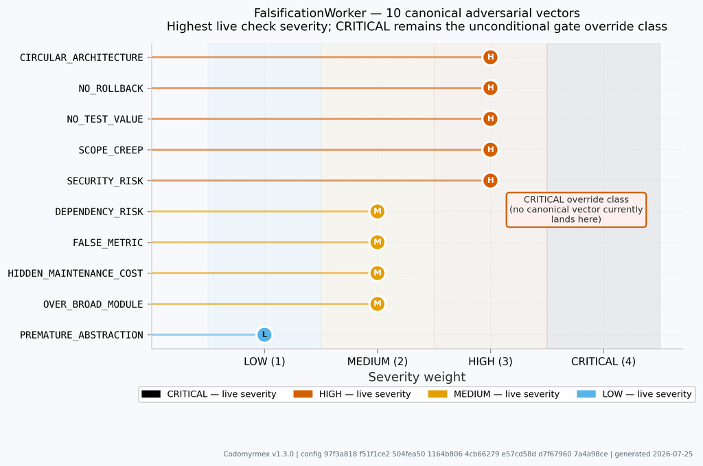

Figure 4: Falsification categories ordered by the highest severity emitted by their live heuristic checks. Colour encodes severity class; one category may be served by more than one check. The empty CRITICAL band denotes the only finding class that hard-refuses before ordinary scoring. The chart is a code-taxonomy visualization, not a measured detection-rate comparison.

## 3.9 Supporting Modules and Research Adapters

Beyond the eight primary subsystems, the Colony Kernel package includes several supporting modules that strengthen verification, configuration, and research extensibility. These modules are part of the checked-in codebase and are exercised by the test suite, but they are not counted among the eight primary control-plane subsystems because they serve verification, configuration, or research roles rather than runtime actuation.

### 3.9.1 Configuration loading (`config_loader.py`)

`config_loader.py` loads YAML-backed configuration from `config/colony_kernel/` (`kernel.yaml`, `roles.yaml`, `decay_rates.yaml`). It provides structured defaults for gate thresholds, trust boundaries, role promotion criteria, and pheromone evaporation rates. The manuscript variable generator reads the same live constants from source, so the configuration file and the code are kept in sync by the `float_mirrors` and `exact_mirrors` validation in `variables.py`.

### 3.9.2 Invariant predicates (`invariants.py`)

`invariants.py` contains executable design-by-contract predicates that check selected properties of the runtime state: gate-weight conservation, trust-score range, pheromone-strength bounds, role-ladder monotonicity, and enum-value separation. The function `all_invariants_hold()` runs all checks against live constants; these predicates are distinct from the SMT obligations in `formal.py` because they execute against runtime values rather than symbolic expressions.

### 3.9.3 Reference gate (`reference.py`)

`reference.py` provides an independent deterministic reimplementation of the gate-scoring arithmetic with parameters that mirror the live gate constants (execute threshold, hold threshold, trust hard floor, etc.). It is used for differential testing: the reference gate and the production `ActuationGate` should produce identical scores for identical inputs. This module is mentioned in Section 11.3 as part of the refinement-test bridge.

### 3.9.4 Formal bridge (`formal.py`)

`formal.py` defines runtime obligations and an optional solver-neutral result bridge. The `KernelFormalSnapshot` dataclass captures a bounded kernel state; `runtime_obligations()` evaluates selected properties (weight conservation, trust range, pressure monotonicity, unrelated-target locality, authorized outcome linkage) against that snapshot. The optional Z3 backend in `formal_verification/z3_bridge.py` translates a subset of these obligations into solver expressions, returning `proved`, `refuted`, `unknown`, `timeout`, or `unavailable` (when Z3 is not installed). The bridge proves or refutes only the encoded bounded obligations; it does not establish whole-program refinement or production safety.

### 3.9.5 Attestation ledger (`attestation.py`)

`attestation.py` implements a versioned, hash-chained execution ledger that binds proposal, verdict, authorization, execution receipt, outcome, rejection, and error events under a configurable signer. The default `HMACSigner` uses constant-time comparison; an optional `Ed25519Signer` uses the `cryptography` library with a delayed import. The ledger supports optional and required attestation modes: in required mode, unlinked outcomes and duplicate nonces are rejected. This ledger is not automatically inserted into the default caller-reported MCP path, so the release does not claim that every outcome report is authenticated. The ledger is exercised by focused tests for replay, omission, duplication, nonce reuse, and unauthorized relinking.

### 3.9.6 Replay harness (`replay.py`)

`replay.py` provides the fixed-input paired-locality replay used to generate the deterministic fixture evidence reported in Section 5.2. The function `run_paired_locality_replay()` constructs a real `ColonyKernel` instance, runs the paired scenario, and returns both semantic and file digests. The replay is repeated for semantic equality; it is not an attestation, causal estimate, or external workload result.

### 3.9.7 Research subpackage (`research/`)

The `research/` subpackage contains offline-first adapters that are not called by the production gate:

- `benchmark.py` — `run_paired_benchmark()` executes deterministic synthetic baseline and mediated traces and computes descriptive safety, utility, refusal, and trace metrics. The paired cases are synthetic; they demonstrate analysis plumbing, not calibration or generalization.
- `metrics.py` — descriptive log loss, Brier score, calibration error, selective risk, and bootstrap confidence intervals.
- `persistent_store.py` — SQLite WAL persistence adapter with crash-injection boundaries for durability testing.
- `probabilistic.py` — `KernelProbabilisticAdapter` declares an observation model, latent-state space, priors, likelihoods, transitions, preferences, and policy horizon. It is research plumbing, not an integrated Active Inference controller.
- `schemas.py` — versioned cases, traces, manifests, and leakage reports.

These adapters preserve the boundary between deterministic runtime contracts and research interpretations. They are exercised by focused tests but do not relabel deterministic gate scores as probabilistic outputs.

## 3.10 The Pressure Loop

The feedback path is composed from separate public operations. `propose_action` returns a decision but does not actuate; `record_outcome` accepts a later caller report but does not currently require a matching authorization. The pseudocode makes that boundary explicit.

**Algorithm 1: Colony Kernel Pressure Loop**

```
Input:  ActionProposal p from any agent
Output: GateResult verdict; side effects on PheromoneStore,
        ResourceLedger, ConsequenceMemory

PROPOSE(p):
         findings ← FalsificationWorker.analyze(p)
             [11 checks; HIGH+ deposits FAILURE, MEDIUM deposits RISK]
         budget_approved ← ResourceLedger.check_budget(p.budget_estimate)
         profile ← ConsequenceMemory.get_profile(p.agent_id)
         profile.total_proposals ← profile.total_proposals + 1
         ConsequenceMemory.save_profile(profile)
         RoleAdapter.update(profile)
         witness ← ActuationGate.witness_state(p)
         hazard ← max(witness.RISK, witness.FAILURE)
         if budget_approved is false:
             decision ← HOLD; gate_score ← 0.0; goto POST_GATE
         if profile.role is SANDBOX or profile.trust_score < 0.3:
             decision ← REFUSE; gate_score ← 0.0; goto POST_GATE
         if any CRITICAL finding:
             decision ← REFUSE; gate_score ← 0.0; goto POST_GATE
         trust_ok ← 1.0 if profile.trust_score >= 0.6 else 0.5
         if ConsequenceMemory.recent_failures(p.agent_id) >= 3:
             trust_ok ← max(0.0, trust_ok - 0.25)
         hazard_ok ← 0.0 if hazard >= 6.0
                  | 0.5 if hazard >= 3.0
                  | 1.0 otherwise
         missing ← [f for f in [rollback_plan, evidence, expected_outcome] if absent]
         completeness ← max(0.0, 1.0 - len(missing) * 0.35) if missing else 1.0
         gate_score ← 0.3 + hazard_ok * 0.3
                      + trust_ok * 0.25 + completeness * 0.15
         gate_score ← max(0.0, min(1.0, gate_score))
         decision ← EXECUTE if gate_score >= 0.75
                   | HOLD   if gate_score >= 0.5
                   | REFUSE otherwise
POST_GATE:
         if decision is REFUSE: deposit FAILURE at p.target
         return GateResult(decision, gate_score, reason, required_evidence)

CALLER MAY ACTUATE AFTER EXECUTE; THE KERNEL DOES NOT ENFORCE THIS STEP.

REPORT(p, outcome, tests_passed):
         [No consumed authorization or duplicate-report check in this release]
         record ← ConsequenceMemory.record(reported consequence)
         ResourceLedger.consume(outcome.cost or p.budget_estimate)
         if tests_passed and no repair: deposit/reinforce SUCCESS
         if tests failed: deposit FAST FAILURE
         deposit SLOW DEPENDENCY at p.target
         profile ← ConsequenceMemory.get_profile(p.agent_id)
         if RoleAdapter.update(profile): ConsequenceMemory.save_profile(profile)
         return record

TICK(): subtract each trace's per-tick evaporation and check budget rollover
PRUNING_REPORT(registry): scan and return candidates; do not archive by default
```

The loop is a deterministic feedback pattern produced by explicit kernel calls: agents propose; callers optionally execute approved work; callers separately report outcomes; trust and local traces then affect later evaluations. Failed outcomes raise same-target hazard pressure and lower the reporting agent’s trust. This can move later proposals from EXECUTE to HOLD or REFUSE, but the effect is bounded by decay and depends on the accuracy of caller-reported outcomes.

On the ordinary path, the generated weights are budget 0.3, hazard 0.3, trust 0.25, and completeness 0.15. Hard overrides intentionally dominate that arithmetic. The score is therefore a transparent policy composition, not a learned collective judgment or calibrated safety probability.

Figure 5 maps the conceptual data dependencies as a 8-stage loop. It shows which state feeds later decisions; it is not a literal call-order trace, because outcome recording is a separate caller action and falsification runs before scoring.

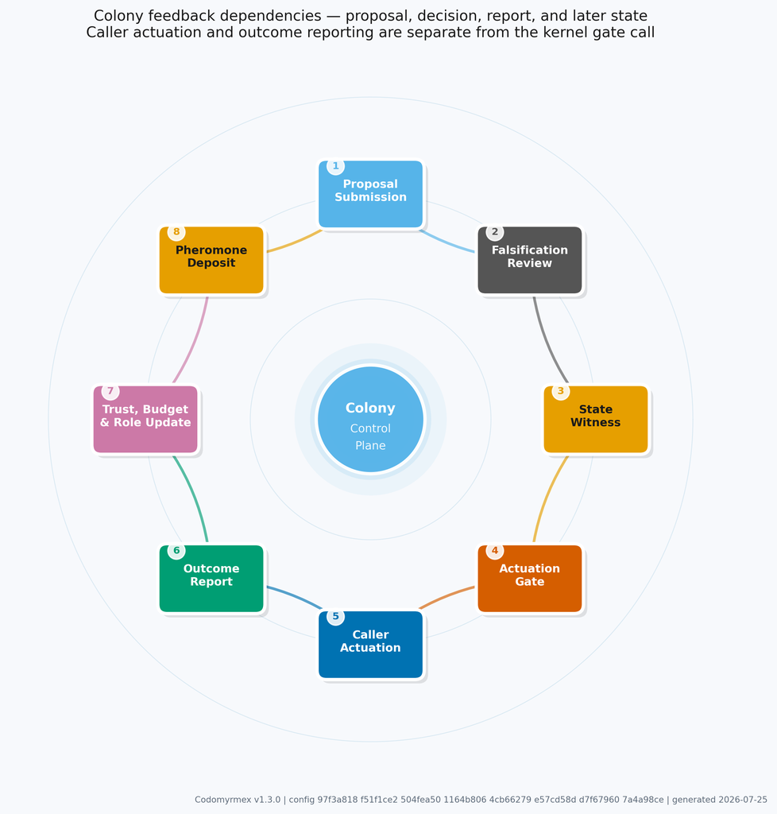

Figure 5: Conceptual Colony Kernel feedback dependencies. Proposal review reads budget, local RISK/FAILURE pressure, role, trust, and completeness; a separate caller may execute an approved action and report its outcome; recording then changes trust, resource usage, and signal traces used on a later proposal. Arrows show feedback dependencies rather than exact runtime call order.

# 4 Evaluation Protocol, Configuration, and Reproducibility Inputs

This section separates a **proposed external benchmark** from the configuration and contract checks that were actually executed for this release. The comparative benchmark has not been run, its baselines are not implemented as released adapters, and no raw trial traces are included. Its purpose here is to make the next empirical test explicit without presenting planned work as evidence.

**Parameter status.** The numeric values shown here are current implementation defaults or illustrative initial settings, not universal constants, fitted parameters, or empirical estimates. They are configurable and can be tuned or replaced through the corresponding runtime policy, configuration, or presentation inputs; after a change, regenerate the tests, tables, figures, and manuscript before interpreting the result. The protocol values reserved in this section are therefore starting points for a preregistered study, not observations or claims about the correct operating point. A study should report every changed value, its authority (runtime policy, configuration, or presentation), and the regenerated artifact hashes.

Table **¿tbl:parameter-classes?** makes the distinction explicit before the proposed trial design and the live runtime configuration are described.

Parameter classes, authorities, and evidence interpretation for the current snapshot. {#tbl:parameter-classes}

| Parameter class | Examples in this release | Interpretation and authority |
| --- | --- | --- |
| Runtime policy | Gate weights, thresholds, trust deltas, decay constants | Current code-defined behavior; tune by changing the runtime policy and rerun the contract suite. |
| Presentation | Plot horizon, grid density, trust slices, checkpoint selection | Reproducible display choices; tune without changing kernel semantics, but regenerate figures and captions. |
| Proposed protocol | Agent count, workload size, warm-up, trial count, seed, baseline conditions | Initial study-design values; they are not completed experiments or observed sample sizes. |

## 4.1 Evidence-status map

Table **¿tbl:evidence-status?** is the release’s claim-status ledger.

Evidence status for the release and proposed study. {#tbl:evidence-status}

| Evidence surface | Release status | Permitted inference |
| --- | --- | --- |
| Colony Kernel unit/integration suite | Executed during variable generation | Checked deterministic behavior under test inputs |
| Ruff and ty checks | Executed; fail closed | No scoped lint/type diagnostics in this snapshot |
| Formula-derived figures and tables | Regenerated from configuration and constants | Arithmetic consequences of the policy |
| 4-condition benchmark | Proposed, not executed | No comparative conclusion |
| Production deployment study | Absent | No production safety or performance conclusion |

### 4.1.1 Proposed independent variable

The proposed study varies the gate policy while holding the ordered workload and reported outcomes constant:

1. **Composite gate** — the released budget, local hazard, trust, completeness, role, and falsification policy.
2. **Static-trust baseline** — a future adapter using only an explicitly specified trust threshold.
3. **Budget-only baseline** — a future adapter using only resource approval.
4. **Always-execute baseline** — a future unsafe control that dispatches every proposal.

Conditions 2–4 are design specifications, not checked-in drop-in implementations. Implementing and testing them is a prerequisite to executing the benchmark.

### 4.1.2 Proposed dependent variables

Table **¿tbl:dependent_variables?** defines the outcomes that a future benchmark must actually record rather than infer from gate decisions alone.

Outcomes required for the proposed benchmark. {#tbl:dependent_variables}

| Variable | Required operational definition |
| --- | --- |
| Decision distribution | EXECUTE/HOLD/REFUSE counts per condition and paired workload item |
| Attested failure rate | Failed, independently verified outcomes divided by consumed EXECUTE authorizations |
| Budget efficiency | Consumed resource units per attested successful task |
| Trust path | Per-agent trust before and after every consumed outcome record |
| Throughput | Attested completed workload items per run |
| Recovery latency | Proposals/ticks from first HOLD until EXECUTE, REFUSE, or expiry |

### 4.1.3 Falsifiable hypotheses

The study should test, rather than assume:

- **H1:** the composite gate lowers attested failure rate relative to always-execute;
- **H2:** same-target failure has a larger subsequent gate effect than failure at an unrelated target;
- **H3:** HOLD provides positive value after accounting for revision cost and delay; and
- **H4:** safety changes are not explained solely by reduced execution volume.

A lower raw error count is insufficient if a policy simply executes less. Results must report denominators, throughput, and paired workload effects.

### 4.1.4 Proposed trial structure

The checked-in configuration reserves 20 run indices, 5 agents, 50 workload items, and 10 warm-up ticks. These are planning parameters only. Before use, the study must provide:

- a versioned workload with stable item identifiers;
- deterministic seeds or a declaration that the run is fully deterministic;
- implemented baseline adapters;
- an authorization ledger linking proposal ID, decision, execution, and one consumed outcome;
- an independent outcome oracle or attestation rule;
- raw append-only traces with configuration and commit hashes; and
- an analysis script that regenerates every reported table and confidence interval.

“Independent trial” should be used only when randomness or independently sampled workloads justify independence. Replaying an identical deterministic trace produces replications for reproducibility, not independent statistical samples.

### 4.1.5 Trust initialization and bootstrap

The default profile begins at trust 0.1 and SANDBOX. The current gate refuses all SANDBOX proposals, including read-only actions, while trust increases only through reported outcomes. Consequently, a trial cannot bootstrap autonomously from this state. A credible benchmark must choose and document one of two approaches:

1. provide a fixed, supervised calibration history before measurement; or
2. implement a restricted, attested SANDBOX action path.

The present all-success trajectory is a deterministic contract fixture using submitted outcomes. It must not be described as naturally earned autonomous authority.

### 4.1.6 Proposed analysis

For paired workload items, report condition-by-item decisions and outcomes before aggregate statistics. Binary attested failure outcomes can be analyzed with paired methods or a mixed-effects model that accounts for workload and agent. Ternary gate decisions require a multinomial or ordinal model appropriate to the design. Pre-register exclusions, multiplicity correction, missing-outcome treatment, and stopping rules. Effect sizes with uncertainty intervals are primary; significance tests are secondary.

## 4.2 Runtime gate configuration

The integrated kernel runs falsification, checks the budget, loads the agent profile, updates its role label, and evaluates the gate. Table **¿tbl:experimental_gate_thresholds?** gives the configured routing bands.

Ordinary gate routing thresholds. {#tbl:experimental_gate_thresholds}

| Outcome | Condition on ordinary score | Runtime meaning |
| --- | --- | --- |
| EXECUTE | score ≥ 0.75 | Caller may actuate |
| HOLD | 0.5 ≤ score < 0.75 | Return revision/recovery requirements |
| REFUSE | score < 0.5 | Reject and deposit FAILURE |

Budget failure, SANDBOX, trust below 0.3, and CRITICAL falsification are evaluated as early returns. Integrated budget failure yields HOLD; standalone gate use yields REFUSE. The score is a policy value, not a calibrated probability.

### 4.2.1 Gate weights

Table **¿tbl:experimental_gate_weights?** identifies each ordinary score component and its live runtime input.

Ordinary gate score components. {#tbl:experimental_gate_weights}

| Component | Weight | Runtime input |
| --- | --- | --- |
| Budget | 0.3 | Binary result of the resource pre-check |
| Local hazard | 0.3 | Piecewise credit from max(RISK, FAILURE) |
| Trust | 0.25 | Tiered trust credit with optional recent-failure penalty |
| Completeness | 0.15 | Presence of rollback, evidence, and expected outcome |

Weights and thresholds are code-defined policy constants with documentation mirrors in YAML. The current release has not calibrated them against external outcomes.

## 4.3 Signal-field configuration

6 `SignalType` values share a capped field. Each trace stores its own subtractive evaporation amount at deposit time; Table **¿tbl:experimental_decay_rates?** reports the 3 configured classes.

Linear field dynamics for a unit trace without reinforcement. {#tbl:experimental_decay_rates}

| Class | Subtraction per tick | Unit trace at report tick | Typical channels |
| --- | --- | --- | --- |
| FAST | 0.3 | 100% lost | FAILURE, RISK |
| NORMAL | 0.1 | generated in Table **¿tbl:linear-decay-values?** | NEED/default |
| SLOW | 0.02 | 80% retained | SUCCESS, DEPENDENCY, HUMAN_PRIORITY |

The runtime caps field strength at 10.0 and floors at zero. Deposits can have source and trust multipliers, so lifetime scales with effective initial strength. The model does not use exponential half-lives.

## 4.4 Resource caps

Values in Table **¿tbl:resource_budget_caps?** are loaded from `config/colony_kernel/kernel.yaml` by the manuscript generator.

Selected period-scoped resource budget caps. {#tbl:resource_budget_caps}

| Dimension | Cap |
| --- | --- |
| LLM calls | 500 |
| Runtime seconds | 3600 |
| Cumulative risk level | 0.8 |
| Security exposure | 0.5 |

The ledger has 7 dimensions in total. The pre-check does not consume resources; `record_outcome` consumes a caller-supplied cost when valid or falls back to the proposal estimate.

## 4.5 Role labels

Table **¿tbl:role_ladder?** distinguishes inferred labels from the authorization behavior that is actually enforced.

Inferred role labels and current enforcement boundary. {#tbl:role_ladder}

| Role | Trust threshold after ≥3 records | Live authorization behavior |
| --- | --- | --- |
| SANDBOX | entry/default | Every proposal hard-refused |
| REPAIR_ANT | 0.2 | No role-specific action matrix beyond leaving SANDBOX |
| MEMORY_ANT | 0.35 | No role-specific action matrix |
| DISPATCHER | 0.5 | No role-specific action matrix |
| GUARD_ANT | 0.7 | No role-specific action matrix |

The labels encode a deterministic ladder and intended specializations. They should not be reported as enforced capabilities until the gate validates action type against role.

## 4.6 Falsification categories

The worker runs 11 checks grouped into these 10 enum categories:

1. `SECURITY_RISK`
2. `NO_ROLLBACK`
3. `NO_TEST_VALUE`
4. `SCOPE_CREEP`
5. `CIRCULAR_ARCHITECTURE`
6. `FALSE_METRIC`
7. `HIDDEN_MAINTENANCE_COST`
8. `DEPENDENCY_RISK`
9. `OVER_BROAD_MODULE`
10. `PREMATURE_ABSTRACTION`

HIGH or CRITICAL findings deposit FAILURE; MEDIUM findings deposit RISK. Only CRITICAL findings are gate hard overrides. The worker’s PASS/CONDITIONAL/FAIL report is not itself the gate decision.

## 4.7 Configuration provenance

3 YAML files under `config/colony_kernel/` document/load kernel budget policy, role metadata, and decay metadata. Runtime authority is mixed:

- `kernel.yaml` is loaded for budget defaults and carries documentation mirrors for some gate constants;
- promotion thresholds are private constants in `role_adapter.py`;
- gate weights, hazard thresholds, completeness penalty, and hard floor are constants in `actuation_gate.py`; and
- per-trace evaporation is derived from `DecayRate` and the base store constant.

The manuscript therefore identifies each value’s runtime authority instead of claiming that every parameter is dynamically configurable. The numeric values shown here are current implementation defaults or illustrative initial settings, not universal constants, fitted parameters, or empirical estimates. They are configurable and can be tuned or replaced through the corresponding runtime policy, configuration, or presentation inputs; after a change, regenerate the tests, tables, figures, and manuscript before interpreting the result.

## 4.8 Software snapshot

Table **¿tbl:software_environment?** records the build-facing tools and generated snapshot facts.

Software used to generate the release evidence. {#tbl:software_environment}

| Component | Snapshot |
| --- | --- |
| Python | 3.14.3 |
| Package manager | uv |
| Test runner | pytest + pytest-cov |
| Linter | Ruff |
| Type checker | ty |
| Config version | 1.3.0 |
| Generated | 2026-07-25T00:53:20Z |

“Generated” is an artifact timestamp. Exact dependency resolution comes from `uv.lock`, not from version ranges in prose.

## 4.9 Manuscript pipeline

The project renderer runs three ordered project steps:

1. `z_generate_manuscript_variables.py` reruns scoped tests, branch coverage, Ruff, and ty; it fails on any non-zero gate and writes the variable/coverage snapshot.
2. `generate_manuscript_figures.py` reads that snapshot and generates the 17 referenced cover/body figures with a provenance footer.
3. `compile_manuscript.py --pdf` hydrates Markdown, checks unresolved tokens, then runs Pandoc with pandoc-crossref and citeproc to produce HTML and PDF.

The template `run.sh` integration invokes the first two scripts as Stage 02 analysis and delegates Stage 03 rendering to the project override. The override normalizes outputs to `output/pdf/codomyrmex_combined.pdf` and `output/web/index.html`. Static manuscript validation runs against the actual `docs/manuscript` source through the shared source resolver.

This pipeline binds internal evidence to the rendered artifact. It does not prove that the proposed external benchmark has been executed.

# 5 Executed Contract Results and Evidence Boundary

This section reports only evidence reproducible from the checked-in Colony Kernel. It distinguishes:

- **executed quality gates**: scoped tests, branch coverage, lint, and static typing;
- **deterministic contract cases**: exact inputs evaluated by real subsystem instances;
- **analytical consequences**: arithmetic derived from the implemented score; and
- **unexecuted evaluation plans**: the comparative benchmark specified in Section 4.1.

No raw multi-condition benchmark trace ships with this snapshot. Accordingly, this section reports no production effect size, confidence interval, ecological optimum, or population-level safety rate.

The numeric values shown here are current implementation defaults or illustrative initial settings, not universal constants, fitted parameters, or empirical estimates. They are configurable and can be tuned or replaced through the corresponding runtime policy, configuration, or presentation inputs; after a change, regenerate the tests, tables, figures, and manuscript before interpreting the result. The analytical figures and deterministic fixtures below should be read as reproducible policy probes, not as measurements of a deployed agent population. Their numerical settings are current example/initial values, not universal constants; they can be tuned through the owning code or configuration, with the full evidence chain regenerated after each change.

## 5.1 Executed quality gates

The fail-closed manuscript generator reruns the Colony Kernel tests and refuses to emit release variables if pytest, Ruff, or ty returns non-zero. Table **¿tbl:quality_gates?** is therefore a snapshot of executed release gates, not a manually entered scorecard.

Executed Colony Kernel quality gates for the rendered snapshot. {#tbl:quality_gates}

| Gate | Snapshot result | Interpretation |
| --- | --- | --- |
| pytest | 814 passing tests | Real tests under `tests/unit/colony_kernel/` |
| branch coverage | 75.5% | Scoped to `src/codomyrmex/colony_kernel` |
| Ruff | 0 findings | Zero required for variable generation |
| ty | 0 diagnostics | Zero required for variable generation |

The suite spans 20 test modules and exercises the 8 named subsystems, their integration class, and the 8-tool MCP adapter. Coverage and passing tests establish exercised behavior under the suite; they do not establish that untested faults, adversarial outcome reports, or deployment failures are absent.

The source snapshot contains 7095 nonblank, noncomment lines across 17 top-level Colony Kernel Python files. These counts describe scope, not quality. The exact commands and evidence limitations are recorded in Section 8.

## 5.2 Paired locality contract

The central implemented claim is evaluated as a paired deterministic case using a real `ColonyKernel`, `PheromoneStore`, `ActuationGate`, and in-memory `ConsequenceMemory`—without mocks.

The fixture uses an authorized agent with trust 0.5, no recent failures, a fully specified proposal, an available budget, and an initially clear target. It then records a failed outcome at that target from another agent and reevaluates both the same target and an unrelated target. Table **¿tbl:paired-locality?** gives the exact results.

Paired same-target inhibition, cross-target isolation, and decay recovery. {#tbl:paired-locality}

| Evaluation | Local RISK | Local FAILURE | Effective hazard | Score | Decision |
| --- | --- | --- | --- | --- | --- |
| Same target, before failure | 0.000 | 0.000 | 0.000 | 0.875 | EXECUTE |
| Same target, after failed outcome | 0.000 | 3.000 | 3.000 | 0.725 | HOLD |
| Unrelated target, after failed outcome | 0.000 | 0.000 | 0.000 | 0.875 | EXECUTE |
| Same target, after 20 passive ticks | 0.000 | 0.000 | 0.000 | 0.875 | EXECUTE |

The failed outcome deposits nominal FAILURE strength 2.0 from source TEST. The 1.5 source multiplier yields pressure 3.000, changing the hazard credit from full to medium. The resulting score change is

$$\Delta g=0.3(0.5-1)
=-0.150 .
\qquad{(20)}$$

The test also establishes locality: the unrelated target is unchanged. A second test establishes reversibility after passive decay. These facts support a bounded statement: the recorded failure increases friction for later same-location action in the running process. They do not show that the original outcome report was truthful, that the effect persists across restarts, or that the gate reduces real-world harm.

The same fixture is replayed twice by `run_paired_locality_replay` with fixed proposal identities and no random draws. The generated semantic digest is

```
af96389d
d276627c 853eeae9 15a54d9a 536e13ff c4d7b74e 9e9f6277 d8b0aabc
```

; the retained JSON artifact is `output/data/colony_kernel_replay.json` with file digest

```
a8718c8b 4394a8bd 3d1197b4 c99c42f8 226f5f64 91875166 59ee9640
5a0653db
```

. Repeatability is an assertion of semantic equality for this fixture, not evidence that the caller-reported outcome was attested or that the implementation is deterministic under concurrency, restart, or external workloads.

Figure 6 summarizes the four semantic states and the repeatability assertion in a compact visual form.

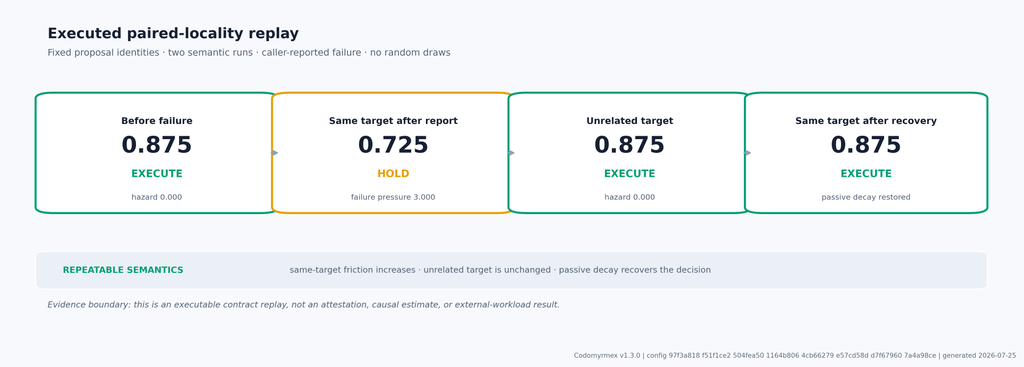

Figure 6: Fixed-input paired-locality replay derived from real Colony Kernel subsystems. The same-target score changes from 0.875/EXECUTE to 0.725/HOLD after a caller-reported failure, while the unrelated target remains at 0.875/EXECUTE with effective hazard 0.000, and passive decay restores 0.875/EXECUTE. The replay is repeated for semantic equality; it is not an attestation, causal estimate, or external workload result. Current default/illustrative policy values; configurable, not empirically calibrated.

## 5.3 Gate landscape and attainable scores

The ordinary gate score has 4 non-negative weighted components. Because trust credit, hazard credit, and completeness are discrete, not every real number in $[0.0,1.0]$ is attainable.

For a lower-tier authorized agent with clear budget and hazard, the score is

$$g(c)=w_b+w_r+w_t\,t_{\mathrm{lower}}+w_c c,
\qquad{(21)}$$

Each coefficient and the lower trust credit are injected from the live gate. Runtime completeness has a finite attainable set because each missing field incurs the generated penalty. Thus the threshold is exact while the discrete input mapping can create gaps; the generated cases below expose those gaps without a second arithmetic source in prose.

Table **¿tbl:representative-gates?** records representative, formula-checked cases.

Representative hard-override and ordinary gate cases. {#tbl:representative-gates}

| Condition | Budget credit | Hazard credit | Trust credit | Completeness | Score | Decision |
| --- | --- | --- | --- | --- | --- | --- |
| SANDBOX, otherwise clear | — | — | — | — | 0.000 | REFUSE override |
| Trust 0.29, otherwise clear | — | — | — | — | 0.000 | REFUSE override |
| Lower trust, clear, no completeness fields | 1.00 | 1.00 | 0.50 | 0.00 | 0.725 | HOLD |
| Lower trust, clear, one of three fields present | 1.00 | 1.00 | 0.50 | 0.30 | 0.770 | EXECUTE |
| Lower trust, medium hazard, complete | 1.00 | 0.50 | 0.50 | 1.00 | 0.725 | HOLD |
| Full trust, high hazard, complete | 1.00 | 0.00 | 1.00 | 1.00 | 0.700 | HOLD |
| Full trust, clear, complete | 1.00 | 1.00 | 1.00 | 1.00 | 1.000 | EXECUTE |

Figure 7 visualizes the controlled slice with budget and completeness fixed at 1.0 and no recent-failure penalty. The vertical discontinuities come from the trust hard floor and trust-credit tier; the horizontal discontinuities come from effective hazard thresholds at 3.0 and 6.0. The pressure axis should be read as $\max(\mathrm{RISK},\mathrm{FAILURE})$, not RISK alone.

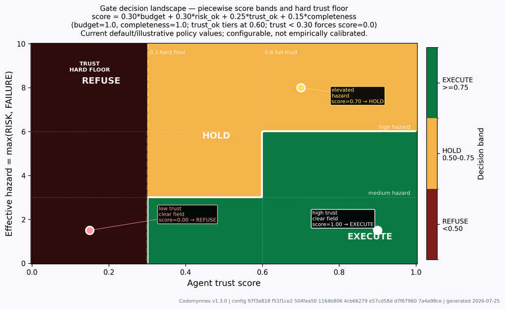

Figure 7: Formula-derived gate decision landscape over trust and effective local hazard pressure, where hazard is the maximum of RISK and FAILURE. Budget and completeness are fixed at 1.0; configured hazard boundaries are 3.0 and 6.0, and trust below 0.3 forces refusal. Colours encode configured decision bands. This is an analytical policy map, not an observed proposal distribution. Current default/illustrative policy values; configurable, not empirically calibrated.

## 5.4 Trust accounting path

A new profile begins at trust 0.1 and role SANDBOX. Along the artificial all-success path, each recorded clean outcome adds 0.04. Table **¿tbl:trust_trajectory?** reports exact checkpoints.

Deterministic all-success trust path from the default profile. {#tbl:trust_trajectory}

| Recorded outcomes | Trust | Inferred role | Gate implication |
| --- | --- | --- | --- |
| 0 | 0.100 | SANDBOX | Role override refuses |
| 3 | 0.220 | REPAIR_ANT | Role changes, but trust remains below the gate floor |
| 5 | 0.300 | REPAIR_ANT | Ordinary scoring reachable |
| 6 | 0.340 | REPAIR_ANT | Ordinary scoring reachable |
| 9 | 0.460 | MEMORY_ANT | Ordinary scoring reachable |
| 12 | 0.580 | DISPATCHER | Ordinary scoring reachable |
| 15 | 0.700 | GUARD_ANT | Ordinary scoring reachable |

The role ladder’s first threshold (0.2) is below the gate’s independent trust hard floor (0.3). Exiting SANDBOX therefore does not itself authorize a proposal.

Figure 8 plots this deterministic path. It is not a convergence plot: alternating or stochastic outcomes need not converge, and the current constant-step clipped update has no restoring term.

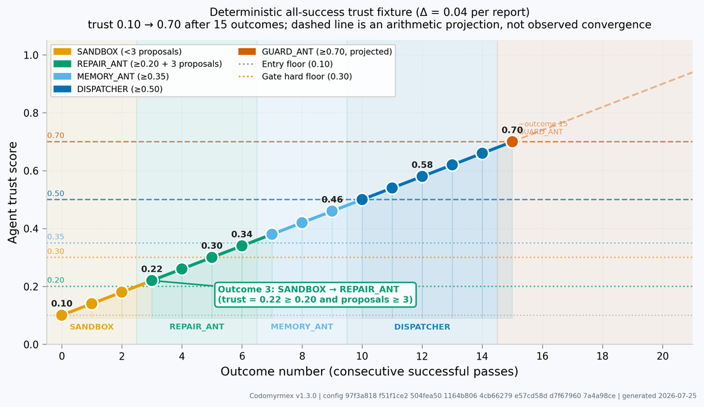

Figure 8: Deterministic trust trajectory under consecutive caller-reported clean outcomes through the configured 15-outcome horizon. Shaded bands show inferred role labels; the independent generated gate floor means the first role promotion does not yet make ordinary gate scoring reachable. Points are analytical applications of the fixed update, not population measurements or evidence of stochastic convergence. Current default/illustrative policy values; configurable, not empirically calibrated.

The fixture is also not an attested credential protocol. The current MCP outcome tool does not require a matching prior EXECUTE record, so an operator or client can submit the reports that drive this path. This is a deployment blocker for adversarial trust.

## 5.5 Subtractive signal dynamics

The field subtracts 0.3, 0.1, or 0.02 per tick for FAST, NORMAL, or SLOW traces, respectively, then removes traces at zero. Table **¿tbl:linear-decay-values?** gives the exact integer-tick path for a unit deposit with no reinforcement.

Exact passive decay of a unit trace under each class. {#tbl:linear-decay-values}

| Tick | FAST | NORMAL | SLOW |
| --- | --- | --- | --- |
| 0 | 1.00 | 1.00 | 1.00 |
| 1 | 0.70 | 0.90 | 0.98 |
| 2 | 0.40 | 0.80 | 0.96 |
| 4 | 0.00 | 0.60 | 0.92 |
| 8 | 0.00 | 0.20 | 0.84 |
| 10 | 0.00 | 0.00 | 0.80 |

Accordingly, a FAST unit trace has lost 100% after 10 ticks, while a SLOW unit trace retains 80%. Figure 1 plots the same recurrence continuously for legibility and states the integer-tick runtime interpretation in its caption.

## 5.6 MCP state and interface boundary

The package exposes the 8 MCP tools summarized in Table **¿tbl:mcp-tools?**.

Colony Kernel MCP interface and state effects. {#tbl:mcp-tools}

| Tool | State effect |
| --- | --- |
| `colony_propose_action` | Runs falsification and gate evaluation; may deposit traces |
| `colony_record_outcome` | Accepts a reported outcome; updates memory, budget, trust, role, and traces |
| `colony_agent_profile` | Reads one profile |
| `colony_status` | Reads the kernel snapshot |
| `colony_pheromone_query` | Reads typed pressure |
| `colony_falsify_plan` | Runs deterministic heuristic review; may deposit traces |
| `colony_pruning_report` | Reads pruning candidates |
| `colony_tick` | Advances decay and period-reset checks |

Requests and responses are self-contained JSON-shaped documents, but calls are not stateless. A module-level `ColonyKernel` singleton shares state across calls within one server process. By default its consequence database is `:memory:` and its field is in-memory; restarting the process loses both. Supplying a file-backed SQLite path can persist consequence records, but the pheromone field still has no restart-persistent backend.

The default MCP compatibility path still has a proposal–outcome linkage gap: `colony_propose_action` does not return a durable authorization record consumed by `colony_record_outcome`, and the outcome tool synthesizes a proposal from caller input. The additive `AttestationLedger` now provides proposal, verdict, authorization, receipt, outcome, rejection, and error events; its optional/required modes reject unlinked outcomes and duplicate nonces. That ledger is not automatically inserted into the default caller-reported MCP path, so this release does not claim that every outcome report is authenticated.

## 5.7 What has not been measured

The current release has not executed the proposed 20-trial, 4-condition benchmark. Consequently:

- the configured trial count is a protocol parameter, not a sample size already observed;
- no refusal percentage is reported as an empirical result;
- no baseline comparison or hypothesis test has been run;
- no throughput, error-rate, budget-efficiency, or trust-stability effect size is claimed; and
- the figures in this paper are code-taxonomy, formula-derived, or deterministic-fixture visualizations—not plots of an external agent population.

This boundary is a result in its own right: it identifies exactly what the internal contract suite establishes and what the next empirical study must supply.

# 6 Scope, Related Work, and Claim Boundaries

The numeric values shown here are current implementation defaults or illustrative initial settings, not universal constants, fitted parameters, or empirical estimates. They are configurable and can be tuned or replaced through the corresponding runtime policy, configuration, or presentation inputs; after a change, regenerate the tests, tables, figures, and manuscript before interpreting the result. This distinction is central to the scholarship: the paper contributes an inspectable implementation and a falsifiable evaluation agenda, not a claim that a hand-specified policy has already been calibrated or shown superior.

## 6.1 Unit of Analysis

The unit of analysis in this paper is the Colony Kernel, not every subsystem distributed with Codomyrmex. The broader repository includes agent, orchestration, model-integration, identity, and other facilities. The claims made here concern the kernel path that combines proposal data, budget state, pheromone readings, consequence-derived trust, role inference, falsification findings, and a ternary gate decision.

This distinction matters for both novelty and evaluation. The Colony Kernel can be used as a control-plane component, but the present artifact does not show that every Codomyrmex action is mediated by it, that external clients cannot bypass it, or that a gate decision is enforced by an operating-system or cloud authorization layer.

## 6.2 Agentic Software Engineering

SWE-bench evaluates model-generated patches against real repository issues, while SWE-agent shows that the agent-computer interface materially shapes software-engineering performance (Yang et al. 2024b, 2024a). These projects motivate evaluating a control plane in the same environments where agents inspect files, run tools, and modify persistent state. They do not provide evidence for the Colony Kernel until the kernel is actually evaluated as part of such a workflow.

LangGraph, AutoGen, and CrewAI provide stateful graphs, conversational multi-agent composition, and role-oriented orchestration, respectively (AI 2024; Wu et al. 2023; Inc. 2024). Their current designs include state or memory facilities, so the Colony Kernel’s positioning does not depend on claiming that other frameworks are stateless or lack cross-session mechanisms. The narrower distinction is architectural: the kernel exposes a deterministic proposal-evaluation path over explicit budget, effective local hazard, trust, and completeness inputs. Whether that path improves outcomes when integrated with another runtime is an empirical question, not a property established by juxtaposing feature lists.

The Model Context Protocol supplies a standard tool-exposure interface (Anthropic 2024). The kernel’s MCP tools make its operations callable by compatible clients, but protocol exposure is not enforcement: a client or tool path that does not invoke the gate is outside the protection claimed here.

## 6.3 What the Colony Kernel Is—and Is Not

**A deterministic governance prototype.** The gate converts a specified kernel state and proposal into EXECUTE, HOLD, or REFUSE. This makes the decision path inspectable and testable.

**Not a complete agent runtime.** The kernel itself does not generate proposals, choose models, execute arbitrary tools, or guarantee that a downstream runtime obeys its verdict. Other Codomyrmex packages may provide adjacent capabilities, but they are not evidence for the kernel claims in this paper.

**Process-lifetime by default.** The MCP module owns a single kernel instance within one process. Consequence memory defaults to SQLite in-memory mode, and the pheromone field is in memory. A caller can choose a file-backed database for consequence records; the default does not provide cross-session persistence, and file-backed consequence records do not by themselves persist the whole kernel or pheromone field.

**Not a per-role authorization system.** RoleAdapter infers labels from trust and proposal count, and SANDBOX is a hard gate condition. The other role labels do not currently define or enforce an action-by-role permission matrix.

**Not a security boundary.** Trust scores are mutable state associated with caller-supplied agent identifiers, not unforgeable capability tokens. The default compatibility outcome path remains caller-reported. An opt-in `AttestationLedger` can authenticate lifecycle linkage and required-attestation mode can reject outcomes without a prior authorization and receipt, but the ledger does not prove that an external observer saw a safe or useful action and is not automatically enabled for every interface.

**Not production- or scale-validated.** The checked-in tests exercise internal contracts. The manuscript does not release the repeated-trial traces, production replays, concurrent load results, or external benchmark runs needed for effectiveness or scaling claims.

**Not an integrated Active Inference implementation.** The core kernel remains deterministic and has no posterior or expected-free-energy policy optimizer. A separate, explicit probabilistic adapter now declares states, observations, likelihoods, priors, transitions, preferences, horizon, and seed for offline research; its presence does not turn gate scores into probabilities or connect that model to production actuation. The comparison in Section 7 remains a design crosswalk.

## 6.4 Stigmergy and Environmental Traces

Grassé introduced stigmergy to describe coordination mediated by changes to a shared environment (Grassé 1959). Digital-pheromone systems later adapted this idea to software-agent coordination (Parunak 1997), while ant-colony optimization formalized reinforcement and evaporation for search (Dorigo and Stützle 2004). The Colony Kernel borrows the environmental-trace idea; it does not implement an ant-colony optimization algorithm.

The TraceField stores strengths under compound location and signal-type keys. Evaporation occurs only when the kernel is explicitly ticked, subtracting a configured amount and deleting depleted markers. This is a deterministic, discrete-time store rather than a continuous diffusion field. Its coordination scope is also bounded by process lifetime in the default MCP configuration.

Signal types must not be conflated. A failed outcome deposits FAILURE and changes the responsible agent’s consequence history; prospective checks may deposit RISK. The gate retains these raw readings for diagnosis and uses their maximum as effective local hazard. Thus a reported failure can tighten a later same-target decision without being silently relabeled as RISK. This coupling is process-local and only as trustworthy as the unattested report that created the FAILURE signal.

## 6.5 Computational Trust and Role Labels

Computational-trust research treats trust as contextual, evidence-dependent, and distinct from simple identity (Marsh 1994; Sabater and Sierra 2005). FIRE combines direct interaction with witness, role-based, and certified evidence (Huynh, Jennings, and Shadbolt 2006). These sources provide comparison points, not validation of the Colony Kernel’s scalar score.

The current kernel uses fixed outcome deltas and clamps the resulting score to a bounded range. It does not estimate a calibrated probability of competence, benevolence, integrity, or future safety. It also does not import witness reputation or certified credentials into the trust update. Two agents with the same score but different sample sizes can therefore receive the same trust tier, and an outcome record has meaning only to the extent that the caller and record are trustworthy.

Role inference is deterministic categorization over this heuristic history. The labels may be useful for routing, explanation, or future policy definition, but only implemented gate conditions have authorization effect. Calling the labels a permission ladder would overstate the artifact until each action class is checked against an explicit policy.

## 6.6 Security Boundary

Capability security requires authority that cannot be obtained merely by naming another principal, while least privilege requires each component to receive only the authority it needs (Miller and Shapiro 2003; Saltzer and Schroeder 1975). A scalar trust score indexed by agent identifier is not such a capability. The gate may contribute evidence to a broader authorization decision, but it must be paired with authenticated identities, non-bypassable mediation, sandboxing, constrained credentials, and downstream policy enforcement.

NIST Zero Trust Architecture likewise requires a broader resource-centric control system, including policy decision and enforcement points, identity and device evidence, and continuous evaluation (Rose et al. 2020). The Colony Kernel is compatible with the general practice of reevaluating proposed actions, but it is not an implementation or certification of NIST SP 800-207.

### 6.6.1 Threat-informed evaluation

Tool-using agents can be redirected by untrusted content, can misuse available tools, and can fail in high-impact simulated environments. AgentDojo and InjecAgent operationalize prompt-injection attacks against tool-integrated agents, and ToolEmu evaluates risks in high-stakes tool use (Debenedetti et al. 2024; Zhan et al. 2024; Ruan et al. 2023). These are appropriate future falsification workloads. They have not been run in this manuscript, so they should not be cited as evidence that the gate reduces attack success.

Runtime-assurance work provides another useful comparison. Simplex architectures interpose a decision mechanism capable of switching from an advanced controller to a verified-safe baseline (Seto et al. 1998). The Colony Kernel also interposes a decision, but it has no verified fallback controller or formal safety invariant. The comparison identifies an engineering direction rather than an inherited guarantee.

External validation agenda; every row is future work rather than a reported benchmark. {#tbl:external-validation-agenda}

| Evaluation question | Suitable evidence | Status in this paper |
| --- | --- | --- |
| Does the gate improve repository-task outcomes? | Controlled SWE-bench or SWE-agent integration with a baseline | Not run |
| Does it reduce unsafe tool use under indirect injection? | AgentDojo or InjecAgent attack-success comparison | Not run |
| Does it reduce high-impact tool failures? | ToolEmu scenarios with linked proposal, verdict, and outcome traces | Not run |
| Can clients bypass or forge control state? | Authenticated end-to-end adversarial tests | Not run |
| Does state survive restart and concurrent access? | Persistence and concurrency tests under a declared deployment configuration | Not established for the default MCP service |
| Are HOLD and REFUSE calibrated to downstream harm? | Held-out outcomes with calibration and utility analysis | Not evaluated |

Table **¿tbl:external-validation-agenda?** states the minimum comparisons needed before making effectiveness or deployment claims.

## 6.7 Active Inference and Free Energy

Friston’s Free Energy Principle (Friston 2010) frames intelligent behavior as minimization of variational free energy—the gap between an agent’s generative model and its sensory observations. A full mapping of the Colony Kernel onto this framework would require an explicit generative model over observations and hidden states, an implemented posterior approximation, and policy selection under expected free energy (Friston et al. 2017).

Section 7 develops this analogy explicitly by proposing a generative-model interpretation of colony observations, hidden states, and policy selection. That treatment is a conceptual reconstruction of the implemented heuristics, not evidence that the current kernel performs variational Bayesian inference or minimizes canonical expected free energy. High failure pheromone concentrations can be read as coarse, persistent prediction-error signals, but the mapping remains an engineering interpretation rather than a proof of formal equivalence.

## 6.8 Explicit Limitations and Future Work

The benchmark protocol in Section 4 remains unexecuted as a repeated comparative study. Configured agent counts, scenarios, and expected rates are protocol parameters or analytical fixtures, not observations. A publication-quality experiment requires released traces, explicit baselines, linked proposal-to-outcome records, predeclared outcomes, and an analysis appropriate to ternary gate decisions.

The current system is synchronous and single-process by default. It has no demonstrated throughput envelope, distributed consistency model, or merge protocol for independent pheromone fields and trust histories. File-backed consequence storage can be evaluated as one deployment option, but it should not be described as persistence of the complete control plane.

The gate weights, trust deltas, role thresholds, decay amounts, and falsification checks are hand-authored heuristics. They are auditable, but auditability is not calibration. Future learning or optimization should predict downstream repair, harm, or policy violation on held-out data; fitting a model to reproduce the existing EXECUTE/HOLD/REFUSE labels would merely imitate the current rule.

Adjacent wallet, HMAC challenge-response, physiological-signal, persona, and spatial world-model modules are outside the evaluated gate path. This paper makes no zero-knowledge, wallet-ownership, coercion-detection, physiological-authentication, or trajectory-aware gating claim on their behalf.

The resulting position is deliberately modest. The Colony Kernel is an inspectable software experiment in consequence-aware gating. Its deterministic contracts are testable now. Persistence across sessions, enforceable role authority, resistance to adversarial clients, and improved safety on realistic workloads remain implementation and evaluation targets. The relevant comparison with prior work is therefore at the level of control-plane decomposition and measurement design; it should not be read as an empirical comparison with the cited systems.

# 7 Active Inference: Bounded Crosswalk and Upgrade Path

Active inference provides a vocabulary for relating perception, belief, action, and learning under uncertainty (Friston 2010; Friston et al. 2017). That vocabulary can help ask sharper questions about the Colony Kernel. It does not, by itself, make the kernel an active-inference system.

The numeric values shown here are current implementation defaults or illustrative initial settings, not universal constants, fitted parameters, or empirical estimates. They are configurable and can be tuned or replaced through the corresponding runtime policy, configuration, or presentation inputs; after a change, regenerate the tests, tables, figures, and manuscript before interpreting the result. The active-inference correspondence below is therefore a research scaffold: it identifies missing model components and testable upgrade steps, not a retrospective theoretical certification of the current heuristic gate. The deterministic settings used in this crosswalk are example/initial engineering values that can be tuned through their owning code or configuration; tuning them does not create a probabilistic model or an empirical Active Inference result.

The core implementation is deterministic and heuristic. It does not integrate a probabilistic generative model, maintain a variational posterior, estimate precision from data, evaluate policies over a planning horizon, or minimize expected free energy. A separate offline research adapter declares these objects for explicit experiments, but it is not called by the production gate and does not relabel deterministic scores. This section therefore presents a conceptual crosswalk and an implementation agenda. Its correspondences are analogies to be tested, not formal equivalences or empirical results.

## 7.1 Canonical Requirements

In a canonical variational treatment, an agent specifies a joint density $p(o,s)$ over observations $o$ and latent states $s$, and maintains an approximate posterior $q(s)$. Variational free energy may be written as

$$\mathcal{F}[q;o]
= D_{\mathrm{KL}}\!\left(q(s)\,\|\,p(s\mid o)\right) - \log p(o),
\qquad{(22)}$$

so minimizing $\mathcal{F}$ in Equation 22 with respect to $q$ makes the approximation approach the posterior under the stated model. Active inference additionally evaluates policies using predicted future observations, preferences, and expected free energy (Friston 2010; Friston et al. 2017).

For a Colony Kernel implementation to satisfy that description, the software would need to represent at least:

1. a declared observation model and latent-state space;
2. priors and an updateable posterior approximation;
3. policies containing possible future action sequences;
4. preferences or costs over predicted outcomes; and
5. an inference procedure that computes or approximates posterior beliefs and policy scores.

The checked-in kernel has deterministic state variables and thresholds instead. Giving those variables names borrowed from active inference does not supply the missing model or inference procedure.

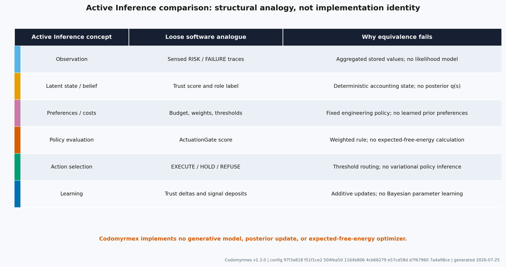

The crosswalk in Figure 9 is therefore a reading aid, not a model diagram. The crosswalk identifies where a future probabilistic implementation might attach to the existing interfaces.

## 7.2 Status of the Proposed Correspondences

Conceptual correspondences and implementation status; the final column is the claim boundary. {#tbl:ai-correspondence-status}

| Active Inference term | Suggested Colony Kernel analogue | Status in the current implementation |
| --- | --- | --- |
| Observation $o$ | Strengths returned by TraceField sensing | Concrete numeric state, but not samples from a declared likelihood |
| Hidden state $s$ | Agent competence or location risk | Interpretive latent quantities; no corresponding random variables are represented |
| Approximate posterior $q(s)$ | Agent trust score or inferred role | Fixed-delta summary and deterministic label, not a probability distribution |
| Policy $\pi$ | ActionProposal | One proposed action, not a policy sequence evaluated over future states |
| Expected free energy $G(\pi)$ | Gate score | Hand-weighted threshold score, not an EFE calculation |
| Precision weighting | Signal source multipliers | Configured deposit weights, not estimated inverse variances |
| Learning | Consequence-derived trust update | Clipped heuristic increments, not posterior or parameter learning |
| Markov blanket | ActuationGate boundary | Software mediation metaphor, not a demonstrated conditional-independence blanket |

Table **¿tbl:ai-correspondence-status?** makes each analogy’s non-equivalence explicit.

### 7.2.1 Trust is not a posterior

The trust score summarizes selected outcome fields by adding fixed positive and negative deltas and clamping the result. It does not retain the sufficient statistics of a declared likelihood, and two agents with different evidence volumes can share the same score. A Beta distribution can be proposed as a future model for binary outcomes, but that model would require explicit assumptions about exchangeability, dependence, nonstationarity, repair events, and human feedback. It cannot be inferred from the current scalar update.

The RoleAdapter adds no Bayesian step. It maps the heuristic score and proposal count to a named tier. Those names remain operating labels; apart from implemented gate conditions such as SANDBOX, they do not constitute a probabilistic belief state or a per-action authorization policy.

### 7.2.2 Signal strength is not prediction error or precision

The pheromone field is useful as a stigmergic store: one operation changes shared environmental state that a later operation can sense. This follows the broad environmental coordination idea in stigmergy (Grassé 1959; Parunak 1997). Within the default MCP server, however, that shared state lasts only for the process and does not constitute a shared generative model.

The signal semantics are also discrete implementation choices. FAILURE and RISK occupy different keys, while the gate computes effective hazard as their maximum. A reported FAILURE can therefore lower the next same-target gate score without becoming a Bayesian risk prior or changing the stored RISK channel. Likewise, source multipliers express configured deposit strength; without a noise model or estimated variance, they are not statistical precision.

Evaporation subtracts a configured amount on each explicit tick and removes depleted markers. It is not exponential Bayesian forgetting, and elapsed wall-clock time has no effect unless a caller advances the kernel.

## 7.3 Gate Decisions and Epistemic Action

The gate combines budget approval, tiered effective hazard, trust, and completeness terms, plus hard conditions, into a deterministic score. No probability distribution over future outcomes is generated, and no alternative policy sequence is rolled out. The gate score should therefore not be identified with $1-G(\pi)$, with a probability of safety, or with an upper bound on harm.

HOLD admits a limited epistemic analogy. A caller may respond to HOLD by supplying better evidence or revising a plan, which can reduce uncertainty for a human or downstream system. The kernel itself does not choose an information-gathering action, compute expected information gain, or guarantee that the revision is informative. HOLD is a request for revision under deterministic rules, not a literal active-inference policy.

EXECUTE has the same boundary. It means that the proposal cleared the current rule under the current state. It does not mean that expected free energy was minimized or that the action is safe.

## 7.4 Environmental Embedding and Markov Blankets

Environmental traces can coordinate successive operations without direct messages, and variational-ecology work offers one theoretical language for studying coupled agents and environments (Ramstead et al. 2019). The Colony Kernel provides a small engineering example of environmental state being sensed after earlier deposits. Demonstrating collective inference would require more: agent-specific models, a shared observation process, and evidence that updates improve posterior prediction or policy selection.

A Markov blanket is a conditional-independence structure in a probabilistic graphical model (Pearl 1988). The ActuationGate is a software boundary between a proposal and a verdict, but this alone does not establish the conditional independencies of a Markov blanket. Calling the gate a blanket is acceptable only as a clearly marked metaphor for mediation.

The process boundary matters here as well. The default MCP singleton lets multiple calls within one process encounter the same in-memory field. Restarting the process removes that field, and a file-backed consequence database does not restore it. Cross-session collective belief propagation is therefore not an implemented property.

## 7.5 From Analogy to an Active Inference Model

Turning the analogy into a scientific model would require a new implementation and a new evaluation, not a relabeling of the existing score.

**Specify the generative model.** Define observable events, latent quantities, likelihoods, priors, conditional independencies, and the time model. FAILURE, RISK, trust, and repair must have distinct semantics in that model.

**Link evidence to actions.** Each observation used for inference should be bound to an approved proposal, executed action, actor identity, and measured outcome. The current ability to submit an outcome without such a chain is unsuitable as an inference dataset.

**Implement posterior inference.** Maintain an explicit posterior approximation and test it using simulation-based calibration, posterior predictive checks, and held-out prediction. A scalar trust score may remain an interface projection, but it should not be treated as the posterior itself.

**Define policies and preferences.** Represent alternative action sequences, future state transitions, and preferred outcomes. Then compute or approximate expected free energy and compare its choices with both the deterministic gate and observed downstream outcomes.

**Calibrate against consequences.** Learning should target repair cost, policy violation, or another independently observed outcome. Training a model to predict the existing EXECUTE/HOLD/REFUSE label would reproduce the current rule rather than validate it.

**Run a comparative experiment.** Release seeds, traces, baselines, and failure analyses for the deterministic gate and the probabilistic alternative. Evidence that the latter improves calibration or utility would support the upgrade; conceptual similarity alone would not.

These steps could yield an active-inference-inspired successor. They would still not prove that the software is formally equivalent to a biological active-inference model; that is a separate mathematical claim requiring explicit definitions and proof.

## 7.6 Summary

Active inference is useful here as a question generator. It asks what the kernel observes, which uncertainty it represents, how evidence changes belief, and how present action is valued against possible futures. The current answers are deterministic strengths, fixed trust deltas, categorical role labels, and thresholded gate decisions.

That architecture may be a practical substrate for later probabilistic work, but the present Colony Kernel performs neither variational Bayesian inference nor expected-free- energy minimization. The honest correspondence is schematic: a map of where formal components might be built, with the unmapped territory left visible.

# 8 Reproducibility Chain, Provenance, and Limits

This section describes the evidence that the checked-in manuscript route actually regenerates. It is a scoped build record, not a claim that every Codomyrmex module was tested, that the Git worktree had no uncommitted edits, or that the proposed external benchmark in Section 4.1 was executed.

The numeric values shown here are current implementation defaults or illustrative initial settings, not universal constants, fitted parameters, or empirical estimates. They are configurable and can be tuned or replaced through the corresponding runtime policy, configuration, or presentation inputs; after a change, regenerate the tests, tables, figures, and manuscript before interpreting the result. The generated snapshot binds the rendered numbers to one configuration and source state; it does not turn those values into fitted or externally validated parameters.

## 8.1 Evidence boundary

Table **¿tbl:repro-scope?** separates the claims supported by the release route from claims that require additional evidence.

Scope of the reproducibility evidence. {#tbl:repro-scope}

| Evidence surface | Regenerated by this route | Not established |
| --- | --- | --- |
| Colony Kernel tests | Pass/fail count for `tests/unit/colony_kernel/` | Correctness outside exercised cases |
| Branch coverage | Coverage of `src/codomyrmex/colony_kernel` against the configured 60.0% floor | Coverage of the full Codomyrmex package |
| Static checks | Ruff and ty status for `src/codomyrmex/colony_kernel` | Repository-wide lint or type cleanliness |
| Manuscript variables | Token map computed from current files, configuration, and gate outputs | A signed or independently attested release |
| Figures | 17 regenerated visual assets sourced from the variable snapshot and documented constants | Measurements from an external agent population |
| Claim audit | Machine-readable claim classes, evidence paths, citations, and boundaries | A claim ledger does not create evidence missing from the cited paths |
| Paired replay | Fixed-input semantic replay with repeat-run equality and JSON digest | Outcome attestation, concurrency, restart durability, or external effectiveness |
| Render | Hydrated Markdown plus HTML/PDF outputs | Byte-identical output across machines and dates |

The variable generator fails when the scoped pytest process, branch-coverage threshold, Ruff, or ty fails. Rendering normally invokes this generator before consuming the hydrated manuscript. “Fail closed” in this paper therefore refers to those named, scoped gates. It does not imply that unrelated repository tests or external benchmark requirements are part of the same decision.

## 8.2 Configuration identity

Table **¿tbl:configuration_provenance?** records the manuscript configuration identity injected into this render.

Configuration identity embedded in the rendered manuscript. {#tbl:configuration_provenance}

| Property | Rendered value | Source |
| --- | --- | --- |
| Configuration digest | `97f3a818 f51f1ce2 504fea50 1164b806 4cb66279 e57cd58d d7f67960 7a4a98ce` | Full SHA-256 over the raw bytes of `docs/manuscript/config.yaml` |
| Experiment replay seed | `0` | Explicit protocol input; the current paired replay uses no random draws |
| Manuscript version | 1.3.0 | `paper.version` in the same YAML file |
| First author | Daniel Ari Friedman | First entry under `authors` |
| Keywords | ai-agents, model-context-protocol, mcp, multi-agent, orchestration, colony-control-plane, stigmergy, artificial-ecology, agentic-software-engineering, falsification-worker, actuation-gate, trust-scori… | `keywords` list |
| Generation time | 2026-07-25T00:53:20Z | UTC time when the variable map was computed |

The configuration digest is a compact change detector for one file. The generated snapshot also records the source commit, worktree state, environment fingerprint, the first-party Colony Kernel/manuscript source digest, lockfile/project hashes, and the authoritative inventory digest below. These values are integrity metadata, not signatures or authenticity proofs.

The generator reads the current filesystem. It can include uncommitted edits, and it does not reject such a state. A release that needs later reconstruction should record the commit and submodule revisions, `git status --porcelain=v1`, any retained diff, the full SHA-256 of `uv.lock`, and hashes of the emitted evidence and publication files. Table **¿tbl:reproducibility_identity?** records the identity fields retained for that reconstruction.

## 8.3 Generated evidence and artifact conventions

Table **¿tbl:artifact_registry?** reports live inventory values available to the manuscript. These are counts of files or definitions visible during generation; they are not all newly created artifacts.

Live release inventory exposed to manuscript tokens. {#tbl:artifact_registry}

| Inventory | Rendered count | Counting rule |
| --- | --- | --- |
| Colony Kernel test modules | 20 | `test_*.py` directly under `tests/unit/colony_kernel/` |
| Colony Kernel YAML files | 3 | `*.yaml` and `*.yml` directly under `config/colony_kernel/` |
| Colony Kernel MCP tools | 8 | `@mcp_tool` definitions in `mcp_tools.py` |
| Colony Kernel documentation files | 3 | `*.md` directly under `docs/modules/colony_kernel/` |
| Top-level Colony Kernel Python files | 17 | `*.py` directly under `src/codomyrmex/colony_kernel/` |

Reproducibility identity recorded for the generated evidence snapshot. {#tbl:reproducibility_identity}

| Reproducibility fact | Rendered value |
| --- | --- |
| Source commit | `aa1a2f97 930b4f6b de81640c 53d9a2a3 8077fdef` |
| Worktree dirty | `true` |
| Environment fingerprint | `12020853 5c15eec4 a8813c45 8940ade8 52f9730c 55fc8611 8a954acf 59ab4da1` |
| Colony Kernel/manuscript source SHA-256 | `51eb3c53 c6dd6fb7 77bad9ed 4e9f5150 e09dcfa9 1dce9d20 111bdb1e 06d372df` |
| `pyproject.toml` SHA-256 | `fdb6feb9 e8ac7b1a 1a507474 beba2943 93abce0f f7938ddb 85f4dc0c 4ab1bf64` |
| `uv.lock` SHA-256 | `666e65eb fc5caaf2 06b68f71 3f900f2c a3985635 c11271a3 1306ce4a 63923c6b` |
| Authoritative inventory SHA-256 | `cbcd02e7 f50e985f d8d54dff 5aadbe1d ef90f3c3 82d7355f b8c02ac2 28e4cb40` |
| Inventory module / MCP file / decorator / workflow counts | `130` / `150` / `623` / `37` |
| Fixed-input replay artifact | `output/data/colony_kernel_replay.json` |
| Replay semantic digest | `af96389d d276627c 853eeae9 15a54d9a 536e13ff c4d7b74e 9e9f6277 d8b0aabc` |
| Replay record SHA-256 | `b49f284d 3e311bcf ccb8f9b1 ce4f6639 719d34d1 f135ab0e 1e476190 d4dfdf26` |
| Replay file SHA-256 | `a8718c8b 4394a8bd 3d1197b4 c99c42f8 226f5f64 91875166 59ee9640 5a0653db` |
| Replay assertions / decisions | repeatable=`true`; same-target=`HOLD`; unrelated=`EXECUTE`; recovered=`EXECUTE` |

Long hexadecimal identifiers in this table are grouped with spaces only to create line-break opportunities in the rendered document. Remove whitespace before comparing them with the machine-readable replay, configuration, or provenance artifacts.

The project uses the following output conventions:

- `output/data/manuscript_variables.json` stores the complete rendered token map;
- `output/data/colony_kernel_coverage.json` stores the fresh scoped coverage report;
- `output/data/colony_kernel_replay.json` stores the fixed-input paired replay, semantic assertions, provenance, and digests;
- `output/manuscript/` stores token-resolved section copies plus `config.yaml` and the bibliography used by the renderer;
- `output/figures/` stores the 17 generated PNG figures and `figure_registry.json`, whose entries record evidence class, byte size, and full SHA-256 for each PNG;
- `docs/manuscript/claim_ledger.yaml` records the active claim audit. The integrity validator checks that every listed source/evidence path exists and that cited bibliography keys resolve;
- direct project compilation writes `output/paper.html` and, with `--pdf`, `output/paper.pdf`; and
- the shared template renderer writes its canonical combined outputs to `output/web/index.html` and `output/pdf/codomyrmex_combined.pdf`.

PDF presentation layout is configuration-backed. The current initial margin is `0.58in`; it is a tunable presentation setting, not a scientific constant or calibrated result. Changing it requires regenerating the variables, figures, HTML/PDF, and integrity manifest, followed by visual inspection. Layout changes do not alter the underlying runtime measurements.

The generated replay JSON is the machine-readable semantic evidence record for the paired fixture; its file digest is injected into the manuscript at generation time.

These paths are generated workspace outputs. Their presence alone does not show that they are current; the successful command log and artifact hashes are needed to bind them to a particular run.

## 8.4 Scoped quality gates

Table **¿tbl:quality_gate_summary?** repeats the same generated values reported in Table **¿tbl:quality_gates?**.

Scoped quality-gate snapshot regenerated for the manuscript. {#tbl:quality_gate_summary}

| Gate | Rendered result | Exact scope |
| --- | --- | --- |
| pytest | 814 passed | `tests/unit/colony_kernel/` |
| branch coverage | 75.5% | `src/codomyrmex/colony_kernel`; 60.0% project floor |
| Ruff | 0 findings | `src/codomyrmex/colony_kernel` |
| ty | 0 diagnostics | `src/codomyrmex/colony_kernel` |

The generator deletes the prior coverage JSON before invoking pytest, requires a newly written report with a branch-coverage percentage, and raises on a non-zero subprocess result. Ruff and ty are also rerun rather than read from a cached scorecard. The test count is parsed from the same scoped pytest process, with a collection-only fallback if the summary cannot be parsed.

The suite introduces no prohibited mock framework and includes real value objects, filesystem cases, and both in-memory and SQLite-backed cases. That testing style checks more integration behavior than isolated substitutes would, but it neither reproduces a production deployment nor validates the truth of caller-reported outcomes.

## 8.5 Exact reproduction commands

The supported repository-level route, from the public template checkout with the ongoing project linked, is:

```bash
uv sync --frozen
./run.sh --pipeline --project ongoing/codomyrmex --core-only
```

The project-local evidence and publication route can be run independently:

```bash
cd projects/ongoing/codomyrmex
uv sync --frozen

uv run python scripts/z_generate_manuscript_variables.py
uv run python scripts/generate_manuscript_figures.py
uv run python scripts/compile_manuscript.py --check --skip-generate
uv run python scripts/compile_manuscript.py --pdf --skip-generate
```

The scoped gates can also be inspected directly:

```bash
uv run pytest tests/unit/colony_kernel/ \
  --cov=src/codomyrmex/colony_kernel \
  --cov-branch \
  --cov-report=json:output/data/colony_kernel_coverage.json \
  --cov-report=term
uv run ruff check src/codomyrmex/colony_kernel
uv run ty check src/codomyrmex/colony_kernel
uv run python scripts/replay_colony_kernel.py
uv run python scripts/validate_manuscript_integrity.py --require-rendered
```

`scripts/compile_manuscript.py --check --skip-generate` checks the hydrated section set for unresolved double-brace variable patterns without rerunning the gates. Omitting `--skip-generate` deliberately regenerates the variables first.

## 8.6 Software environment

Table **¿tbl:software_versions?** records the environment facts that are available to this manuscript without inventing cross-platform certification.

Software inputs relevant to reproduction. {#tbl:software_versions}

| Component | Release fact | Reproducibility role |
| --- | --- | --- |
| Python | 3.14.3 | Interpreter used by variable generation |
| uv | Resolved from the installed tool | Installs the locked dependency graph |
| `uv.lock` | Repository lockfile | Pins Python package resolution |
| pytest / pytest-cov | Development dependencies | Executes tests and branch coverage |
| Ruff / ty | Development dependencies | Executes scoped static gates |
| Pandoc / XeLaTeX | Host tools | Produce HTML/PDF; versions can affect layout |
| SQLite | Python standard-library binding | Exercises consequence storage where configured |

`uv sync --frozen` prevents dependency re-resolution, but it does not pin host fonts, Pandoc, TeX packages, operating-system libraries, or the current date. The generation timestamp and auto publication date also change across runs. Consequently, the expected claim is semantic regeneration with passing gates and resolved references—not universal byte-for-byte identity.

## 8.7 Evaluation snapshot

Table **¿tbl:evaluation_snapshot?** identifies what the current snapshot contains.

Contents and omissions of the release evaluation snapshot. {#tbl:evaluation_snapshot}

| Item | Status | Evidence path |
| --- | --- | --- |
| Gate/test/type/lint values | Executed during variable generation | `output/data/manuscript_variables.json` |
| Branch details | Executed during variable generation | `output/data/colony_kernel_coverage.json` |
| Policy and taxonomy figures | Regenerated | `output/figures/*.png` |
| Deterministic contract cases | Executed by the Colony Kernel suite | `tests/unit/colony_kernel/` |
| Paired replay artifact | Executed twice with fixed identities and compared semantically | `scripts/replay_colony_kernel.py` and `output/data/colony_kernel_replay.json` |
| Four-condition benchmark | Proposed only | No raw trial artifact in this release |
| Production deployment | Not evaluated | No production trace artifact |

Core score calculations and tick updates are deterministic for fixed explicit inputs and state. The full build is not purely deterministic: proposal identifiers and timestamps may be created at runtime, the manuscript records a generation time, the publication date may be automatic, and renderer versions can alter layout. Replaying an identical policy case is therefore different from reproducing identical publication bytes.

## 8.8 Evidence required for the proposed external study

The comparative study in Section 4.1 should not be promoted to “executed” until the artifacts in Table **¿tbl:external-evidence?** exist and regenerate the reported analysis.

Minimum external evidence needed for a comparative evaluation claim. {#tbl:external-evidence}

| Required artifact | Minimum content |
| --- | --- |
| Workload manifest | Stable item IDs, inputs, expected evaluation procedure, licenses, and exclusions |
| Baseline implementations | Versioned adapters for all four conditions with shared interfaces |
| Authorization/outcome ledger | Proposal, gate decision, consumed execution authorization, outcome, and attester identity |
| Raw event trace | Append-only ordered events, costs, decisions, outcomes, ticks, and errors |
| Run identity | Source commit, submodule revisions, full configuration and lockfile hashes, environment inventory |
| Analysis package | Script or notebook that regenerates tables, figures, uncertainty intervals, and exclusions |
| Negative evidence | Failed runs, missing outcomes, protocol deviations, and stopping decisions |

Until that package exists, the manuscript’s strongest supported conclusion remains the bounded one reported in Section 5: the checked implementation exhibits the tested local inhibition, recovery, scoring, and accounting behavior under its contract cases.

# 9 Conclusion: What the Release Establishes

This paper presents the Colony Kernel as a deterministic, inspectable prototype for placing a control decision between an agent’s proposal and software actuation. Within the kernel evaluation path, a proposal is considered alongside budget headroom, local hazard pressure, consequence-derived trust, proposal completeness, the agent’s inferred role label, recent failures, and falsification findings. The result is an explicit EXECUTE, HOLD, or REFUSE decision rather than an implicit assumption that possession of a tool implies permission to use it.

The implementation evidence supports a bounded claim. The checked-in tests exercise the kernel’s data models, gate arithmetic, consequence updates, pheromone operations, role inference, and MCP-facing tools. These tests establish deterministic software contracts for the cases they cover. They do not establish production safety, robustness at scale, resistance to a strategic adversary, or improved task performance relative to another agent runtime.

The numeric values shown here are current implementation defaults or illustrative initial settings, not universal constants, fitted parameters, or empirical estimates. They are configurable and can be tuned or replaced through the corresponding runtime policy, configuration, or presentation inputs; after a change, regenerate the tests, tables, figures, and manuscript before interpreting the result. The current figures and fixtures should therefore be changed only through a declared tuning or calibration protocol with regenerated tests, tables, figures, and provenance—not silently treated as universal constants.

Several boundaries are especially important. The default MCP server owns one kernel instance for the lifetime of its process. Its consequence database defaults to SQLite in-memory mode, and its pheromone field is also in memory. A caller may configure a file-backed SQLite path for consequence records, but that does not persist the complete kernel state or the pheromone field. The present artifact therefore does not support a claim that local pressure, trust, or gate state automatically survives process restarts, model swaps, or deployment across machines.

The role ladder is similarly narrower than an authorization hierarchy. RoleAdapter deterministically maps trust and proposal-count state to labels, and SANDBOX receives a hard gate override. The remaining role names do not currently carry an action-specific permission matrix. They describe inferred operating status; they are not cryptographic capabilities or independently enforced privilege scopes.

The FAILURE and RISK channels remain distinct in storage, but they are now coupled at the gate: local hazard is the maximum of the two sensed pressures. The paired contract test records a failed outcome, observes the resulting FAILURE pressure, and changes a complete same-target proposal from EXECUTE to HOLD while leaving an unrelated target unchanged. Passive tick decay later restores the original decision. This verifies a process-local locality invariant. It does not verify the truth of the outcome report: the MCP outcome endpoint still accepts caller-supplied data without binding it to a prior EXECUTE authorization or independently observed actuation.

## 9.1 Falsification Criteria and Evaluation Agenda

The architecture should be judged by tests that can fail, not by the biological metaphor. The following criteria separate contracts already exercised by the repository from claims that still require implementation or empirical evaluation.

### 9.1.1 F1: Failure-to-gate coupling

The checked-in paired test submits identical proposals under identical agent, budget, completeness, and falsification state, varying only whether the target location has a reported failed outcome. The failed-location proposal receives a strictly lower score and a stricter decision; an unrelated location does not. The remaining falsification criterion is end-to-end attestation: the same result must hold when FAILURE can only be created from a prior authorized action and an independently observed adverse outcome.

### 9.1.2 F2: Deterministic gate evaluation

Two evaluations with the same complete kernel state and proposal must produce the same score, decision, and stated reasons. Complete state includes the inferred role, budget, effective local hazard, trust tier, completeness tier, recent-failure count, and any CRITICAL finding. This is a software determinism criterion; it is not a claim that the resulting decision is calibrated to real-world harm.

### 9.1.3 F3: Bounded trust updates

For clean outcomes and zero human feedback, trust should increase by the configured pass delta while the score remains below its upper clamp. At the boundary, the clamp must be included in the expected result. The analogous checks apply to failed tests, repair requirements, and negative feedback. Passing these checks establishes arithmetic consistency, not that the heuristic deltas are statistically optimal.

### 9.1.4 F4: Role-label determinism and authorization separation

At each documented trust and proposal-count boundary, RoleAdapter should return the specified label. A separate negative test should confirm the current limit: beyond the SANDBOX override and other gate conditions, non-sandbox role labels alone do not enforce which action types an agent may perform. Any future per-role permission claim requires a policy matrix and action-level enforcement tests.

### 9.1.5 F5: Adversarial and restart behavior

An external evaluation should test unlinked outcome submission, agent-identifier reuse, semantically empty completeness fields, process restart, concurrent clients, budget-window timing, and poisoning of shared state. These cases probe assumptions that deterministic unit tests cannot settle.

Evidence boundary and falsification agenda; external benchmark rows are future work, not reported experiments. {#tbl:falsification-benchmarks}

| Question | Evidence in this artifact | Publication-honest status |
| --- | --- | --- |
| Is gate arithmetic deterministic for covered fixtures? | Checked-in unit and contract tests | Supported within the tested state space |
| Does reported FAILURE tighten same-target local gating? | Paired contract test over `max(RISK, FAILURE)` | Supported within one kernel process |
| Do role labels enforce per-action permissions? | SANDBOX override; no general role/action matrix | Not implemented |
| Does colony state survive a default MCP process restart? | In-memory default database and field | No |
| Does the kernel reduce unsafe actuation on external workloads? | Proposed protocol; no released trial traces | Not yet evaluated |
| Does the kernel remain correct under production concurrency or scale? | Single-process implementation and local tests | Unverified |

Table **¿tbl:falsification-benchmarks?** keeps implemented contracts separate from open external claims.

## 9.2 Limitations and Next Work

The experimental protocol in Section 4 is a specification for future evaluation. The repository does not currently provide the raw repeated-trial traces, baseline runs, or external workload results needed to estimate refusal rates, repair rates, latency, or safety benefit. Consequently, configured scenario counts and expected rates should not be read as measured outcomes.

The gate weights, trust deltas, decay amounts, role thresholds, and falsification checks are fixed engineering heuristics. They have not been calibrated against downstream harm or production repair cost. The falsification worker is also a deterministic proposal checker, not a proof of semantic safety: only CRITICAL findings independently force a gate refusal, and syntactically complete but misleading evidence may evade its checks.

Four implementation priorities follow directly from these limits. First, bind outcome records to prior EXECUTE authorizations, observed effects, and authenticated agent identities. Second, persist and reconcile the entire field and budget state when cross-session behavior is required. Third, define and enforce an action-by-role authorization policy if role names are to carry security meaning. Fourth, run the proposed paired and external benchmarks with released traces, explicit baselines, and predeclared outcome measures before making effectiveness or scale claims.

The Colony Kernel’s present contribution is thus a testable control-plane scaffold. It makes selected state transitions and decision rules visible enough to inspect, replay within a process, and challenge. That is useful groundwork, but it is not yet evidence that the colony becomes safer merely by accumulating history. In this version, the record is evidence for a control decision—not a guarantee that the decision is correct.

# 10 Research Roadmap: Evidence Gates and Dependency Order

The numeric values shown here are current implementation defaults or illustrative initial settings, not universal constants, fitted parameters, or empirical estimates. They are configurable and can be tuned or replaced through the corresponding runtime policy, configuration, or presentation inputs; after a change, regenerate the tests, tables, figures, and manuscript before interpreting the result. This roadmap is a scoped research program, not a catalogue of completed results. The current paper establishes the reproducible kernel contract and a fixed-input paired replay artifact; subsequent milestones are conditional on their artifacts, metrics, falsifiers, and exit criteria. A status label therefore describes evidence available in the current repository, not a promise about delivery or scientific success.

## 10.1 Research question and boundary

The central question is whether a proposal-governance control plane can improve the safety–utility trade-off of agentic software work when its state is authenticated, evaluated under hostile inputs, and calibrated against independently observed consequences. The implementation currently supports a narrower statement: a caller-reported failure changes same-target local pressure in a running kernel process, and the deterministic gate responds according to its configured rule. The roadmap does not promote that mechanism into a claim of harm reduction, optimality, collective intelligence, or Active Inference.

The milestones are ordered by dependency. Replayable artifacts must precede external comparisons; authenticated outcome linkage must precede trust calibration; adversarial and held-out evaluation must precede claims about utility; and persistence/concurrency evidence must precede deployment-oriented interpretation. This ordering follows reproducibility and accountability principles rather than a calendar commitment (Peng 2011; Raji et al. 2020; Buhl et al. 2024).

The synthetic benchmark record also retains the case-manifest digest `74e664af b4e22a35 873995a8 15e21dca 88118e2e eb20848e 39acf99b 110a2ca8`, paired execution volumes of `6` and `3`, and the descriptive interval method `paired percentile bootstrap` at a nominal `95%` confidence level. These metadata bind the displayed fixture to its ordered task cases; they do not turn six synthetic pairs into an estimate of population risk or utility.

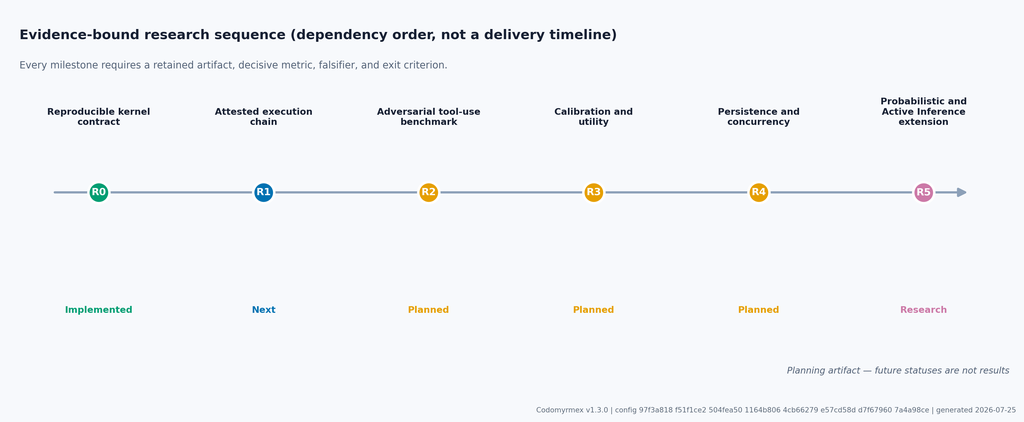

Figure 10: Configured research roadmap for the Colony Kernel. The 6 milestones move from the implemented contract and replay record toward attested execution, adversarial evaluation, calibration, persistence, and a probabilistic extension. Status labels describe the current research state, not empirical results or delivery guarantees; each milestone remains conditional on its stated artifact, metric, falsifier, and exit criterion.

The first executable evidence fixtures are separated by what they can and cannot establish. The attestation chain binds local lifecycle events, the paired benchmark exposes the safety–utility analysis plumbing, and the persistence fixture checks restart state. None is an external benchmark, causal estimate, or production security guarantee. The figures below are generated artifacts with declared boundaries, not evidence that the later research milestones have been completed.

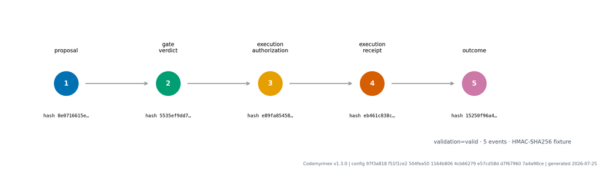

Figure 11: Authenticated local lifecycle fixture with 5 linked events and validation status true. The chain binds proposal, verdict, authorization, execution receipt, and outcome digests under the configured signer; it establishes ledger integrity, not that the action was safe, useful, or independently observed.

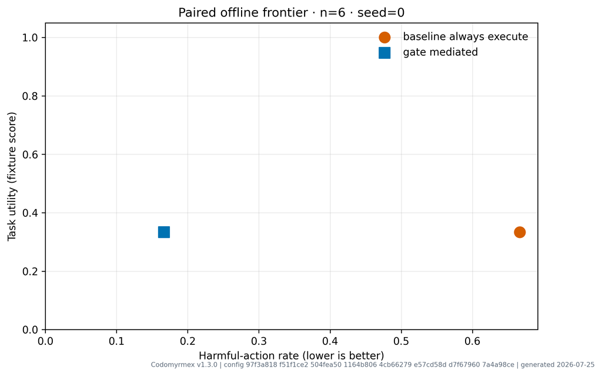

Figure 12: Paired safety–utility points from 6 deterministic synthetic tool-use cases. Baseline and mediated harmful-action rates are 0.667 and 0.167, with utilities 0.333 and 0.333. The paired harmful-action difference is -0.500 with a descriptive percentile-bootstrap interval at a nominal 95% confidence level [-0.833, -0.167]. The interval uses task-case pairs, not a population sample. This fixture demonstrates analysis plumbing, not calibration or generalization to external agents or workloads.

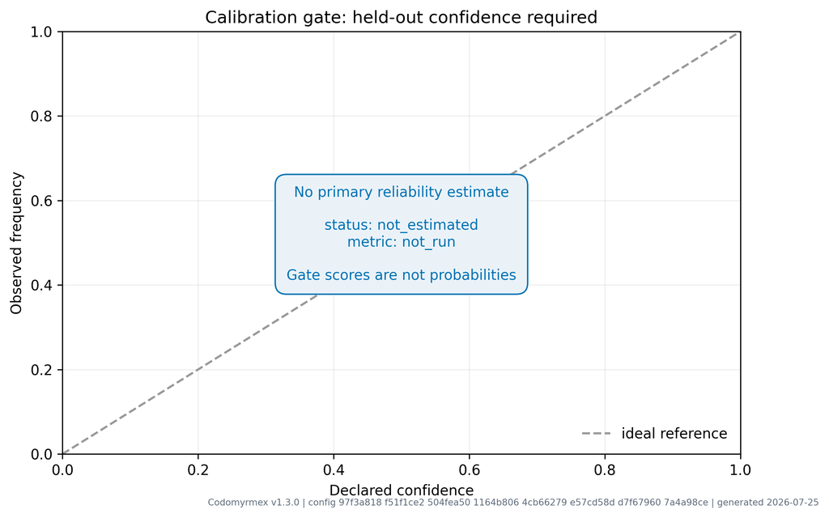

Figure 13: Calibration status panel for the current evidence bundle: primary calibration is not_estimated and log-loss analysis is not_run. Gate scores and trust values are not probabilities; a reliability estimate will be rendered only after independently observed held-out outcomes and declared confidence values are available.

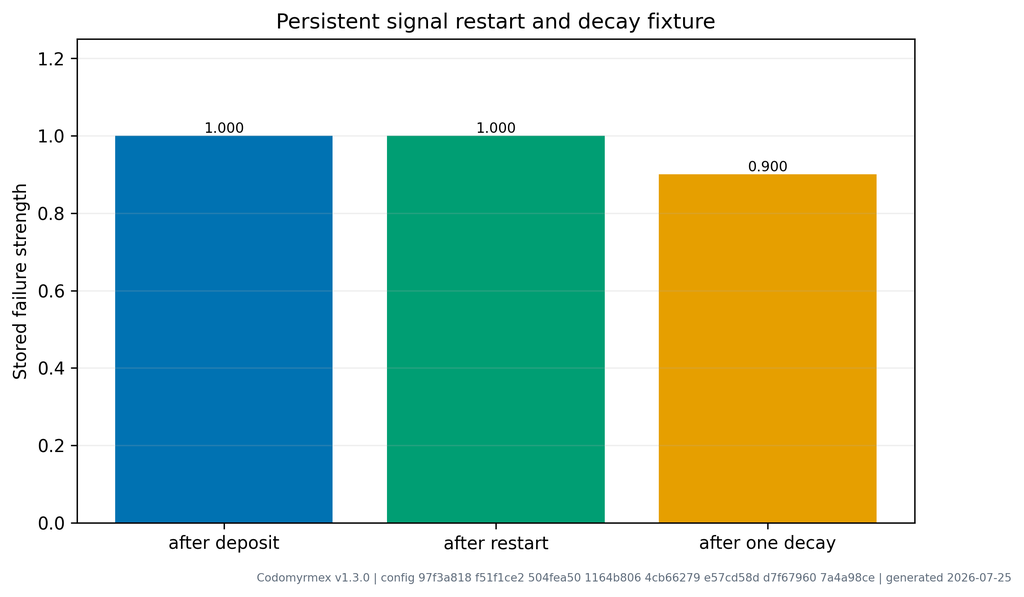

Figure 14: SQLite-backed signal restart fixture. The retained failure signal after closing and reopening the store is 1.000; the durable canonical logical database artifact digest is 464fd1d9 9088a6c0 99059f13 25d1494e 5fe12a90 f46d4ec4 ae9c0e2a daa0635d. This is a durability check, not a throughput or crash-survival claim.

The roadmap in Figure 10 is a dependency map, not a delivery timeline. Its future milestones are planning objects and must not be read as empirical evidence.

The first offline research fixtures are shown alongside the roadmap: the authenticated event chain in Figure 11, the paired safety–utility plumbing in Figure 12, the explicit calibration hold in Figure 13, and the restart check in Figure 14.

## 10.2 Milestone contract

The complete configured program contains 6 milestones. Each row states what would be built, measured, falsified, and accepted; empty claims are not allowed to advance by narrative momentum.

Evidence plan for the configured research milestones. {#tbl:research-roadmap-evidence}

| ID | Milestone | Status | Hypothesis | Required artifact |
| --- | --- | --- | --- | --- |
| R0 | **Reproducible kernel contract** | Implemented | The local control-plane contract can be replayed from the checked-in source and configuration. | Scoped tests, coverage record, variable map, figure registry, and rendered manuscript. |
| R1 | **Attested execution chain** | Next | Binding proposal, authorization, execution, and outcome records will reduce untrustworthy feedback. | Authenticated event ledger with nonce, actor, proposal digest, verdict, and outcome evidence. |
| R2 | **Adversarial tool-use benchmark** | Planned | Gate-mediated proposals will change unsafe-action and recovery outcomes under hostile tool inputs. | Seeded AgentDojo, InjecAgent, or ToolEmu adapter with paired baseline traces. |
| R3 | **Calibration and utility** | Planned | Gate scores can be calibrated against independently observed downstream consequences. | Held-out outcome dataset, baseline policies, calibration analysis, and preregistered configuration. |
| R4 | **Persistence and concurrency** | Planned | Explicit persistence and concurrent access can preserve locality without violating isolation or ordering. | Restart, crash-recovery, multi-worker, and load scenarios under a declared deployment profile. |
| R5 | **Probabilistic and Active Inference extension** | Research | An explicit generative model can improve prediction or policy selection beyond the heuristic projection. | Declared likelihood, posterior implementation, simulation-based calibration, and paired baselines. |

Decision contract for the configured research milestones. {#tbl:research-roadmap-decision}

| ID | Decisive metric | Falsifier | Exit criterion |
| --- | --- | --- | --- |
| R0 | Replay agreement for gate, locality, decay, and provenance outputs. | Any replay depends on an undocumented input or produces a contradictory contract result. | Fresh generation and focused gates pass with hashes recorded. |
| R1 | Forgery and replay rejection, linkage completeness, and overhead under declared workloads. | A caller can submit or relink an outcome without possessing the required execution evidence. | Adversarial ledger tests pass and the attestation boundary is documented. |
| R2 | Attack success, harmful-action rate, task utility, refusal cost, and complete trace retention. | The mediated condition does not improve the preregistered safety-utility frontier. | Independent rerun reproduces paired estimates and failure analyses. |
| R3 | Log loss, calibration error, selective risk, repair cost, utility, and confidence intervals. | Scores remain miscalibrated or add friction without a defensible utility trade-off. | Held-out analysis and uncertainty intervals are released with raw traces. |
| R4 | Durability, ordering, isolation, throughput, latency, and recovery completeness. | Restart or concurrency causes silent signal loss, cross-target contamination, or unsafe duplicate actuation. | Scenario matrix passes with retained logs, seeds, environment, and artifact hashes. |
| R5 | Posterior predictive checks, held-out log loss, calibration, policy utility, and compute cost. | The probabilistic model fails calibration or utility comparisons, or its assumptions are not identifiable. | Model, assumptions, replay harness, and negative results are independently reproducible. |

The evidence plan in Table **¿tbl:research-roadmap-evidence?** and decision contract in Table **¿tbl:research-roadmap-decision?** are generated from `docs/manuscript/config.yaml`; they are not a second authority for parameters or results. The variable snapshot records the exact roadmap configuration, while the figure registry records the rendered planning visual and its hash. R0 additionally retains the replay’s semantic and file digests shown in Table **¿tbl:reproducibility_identity?**. The implemented R0 row is accepted only when its configured `artifact_paths` resolve to checked-in source or evidence surfaces; future rows remain hypotheses until they acquire equivalent retained paths.

## 10.3 Execution protocol

Every future study should retain the following minimum evidence bundle:

- the source commit, environment fingerprint, lockfile digest, configuration digest, random seed, and input checksums;
- raw append-only proposal, verdict, execution, and outcome traces, including rejected and failed cases rather than only successful runs;
- the baseline policy, the mediated policy, and the exact paired assignment rule;
- analysis code that computes point estimates, uncertainty intervals, calibration diagnostics, and failure stratifications; and
- generated tables, figures, captions, and a machine-readable manifest linking each claim to its source artifact.

This bundle turns a research result into a replay target. It does not require a claim to be positive: a well-specified null result or failed falsification attempt is publishable evidence when its inputs and analysis remain inspectable. Model cards and safety cases are useful reporting analogies, but their presence does not substitute for the linked execution evidence (Mitchell et al. 2019; Buhl et al. 2024).

## 10.4 Decision rules for promotion

Promotion from one milestone to the next requires all of the following:

1. the artifact is complete and independently replayable;
2. the decisive metric is computed on the declared comparison rather than on the gate labels it is intended to validate;
3. uncertainty, missingness, and adverse cases are reported;
4. the stated falsifier has been evaluated without silently changing the protocol; and
5. the result does not exceed the claim boundary of the implementation or the data.

If a milestone fails its falsifier, the next action is diagnosis, redesign, or a bounded negative result—not relabeling the failure as a successful ecological effect. In particular, training a predictor to reproduce EXECUTE/HOLD/REFUSE labels would validate the existing rule’s behavior, not its downstream usefulness. Utility must be measured against independently observed repair cost, policy violation, task completion, or other outcomes specified before analysis.

## 10.5 Relation to the active-inference track

The final milestone depends on the distinctions in Section 7. A probabilistic extension must declare observations, latent states, likelihoods, priors, posteriors, policies, preferences, and an inference procedure. It must then be compared with the current deterministic gate using posterior predictive checks, simulation-based calibration, held-out log loss, utility, and compute cost. Naming a trust score a posterior or a gate score expected free energy would not satisfy that contract.

The roadmap therefore treats Active Inference as a falsifiable modeling direction rather than a retrospective interpretation. This is consistent with the current crosswalk’s claim boundary and with the broader positioning against tool-use security and runtime assurance: cited external benchmarks motivate adapters and threat models, but none is evidence for the Colony Kernel until the experiment is actually run (Debenedetti et al. 2024; Zhan et al. 2024; Ruan et al. 2023; Seto et al. 1998).

## 10.6 Scope of this release

The current release documents and validates the first milestone’s local contract, fixed-input replay, and reproducibility route. It does not claim that the later milestones are complete, that the provisional settings are calibrated, or that the control plane is a security boundary. The appropriate scholarly contribution at this stage is a composable, inspectable research substrate with explicit failure conditions and a machine-readable path from configuration to prose, tables, figures, and artifacts.

# 11 Formalism-to-Code Crosswalk and Translation Methods

The repository uses several kinds of formal description: typed operational contracts, discrete recurrences, piecewise decision rules, executable invariants, AST-preservation rules, optional SMT obligations, and probabilistic inference components. These formalisms are complementary, but they are not interchangeable. A formula in a document is not a property of the software until the variables, state transition, implementation mapping, and verification boundary are made explicit.

The numeric values shown here are current implementation defaults or illustrative initial settings, not universal constants, fitted parameters, or empirical estimates. They are configurable and can be tuned or replaced through the corresponding runtime policy, configuration, or presentation inputs; after a change, regenerate the tests, tables, figures, and manuscript before interpreting the result. This section makes that translation chain inspectable. It does not claim that every formalism has been connected to the Colony Kernel, and it does not treat a shared word such as *trust*, *state*, or *policy* as evidence of semantic equivalence.

## 11.1 A five-link translation chain

The crosswalk uses five links for every formal claim:

1. **Formal object.** State the mathematical or logical object, its variables, domains, and assumptions. If a probability model is intended, declare the sample space, likelihood, prior, posterior, and policy variables rather than naming a scalar as a posterior by analogy.
2. **Code representation.** Identify the typed value objects, enums, state holders, or functions that represent the object. The representation may be partial; that fact is recorded rather than inferred away.
3. **Translation mechanism.** State how the formal object is computed from or imposed on code: a constructor guard, state-transition function, recurrence, AST comparison, schema adapter, or sound symbolic encoding.
4. **Executable evidence.** Name the tests, replay artifacts, solver obligations, or generated outputs that exercise the translation. A test of a wrapper is not silently promoted to a proof of the wrapped system.
5. **Claim boundary.** State what the evidence supports and the strongest nearby claim it does not support. This final link prevents a local invariant from becoming a claim of safety, utility, biological equivalence, or production reliability.

This discipline follows design-by-contract and formal-methods practice (Apt 2003), while the retained configuration, source anchors, and generated artifacts follow the broader requirements of reproducible and accountable computation (Peng 2011; Raji et al. 2020; Buhl et al. 2024).

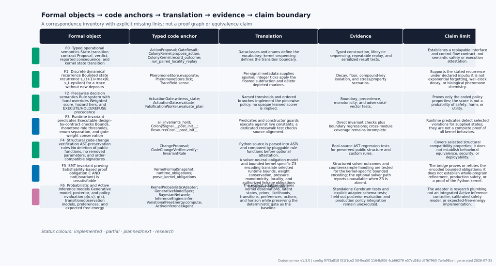

Figure 15: Evidence-oriented crosswalk from formal objects to typed code anchors, translation mechanisms, executable evidence, and claim boundaries. Green rows are implemented contracts, blue rows are partial bridges, and amber/pink rows are future integration work. The visual records correspondence and missing links; it is not a proof graph or evidence of scientific equivalence.

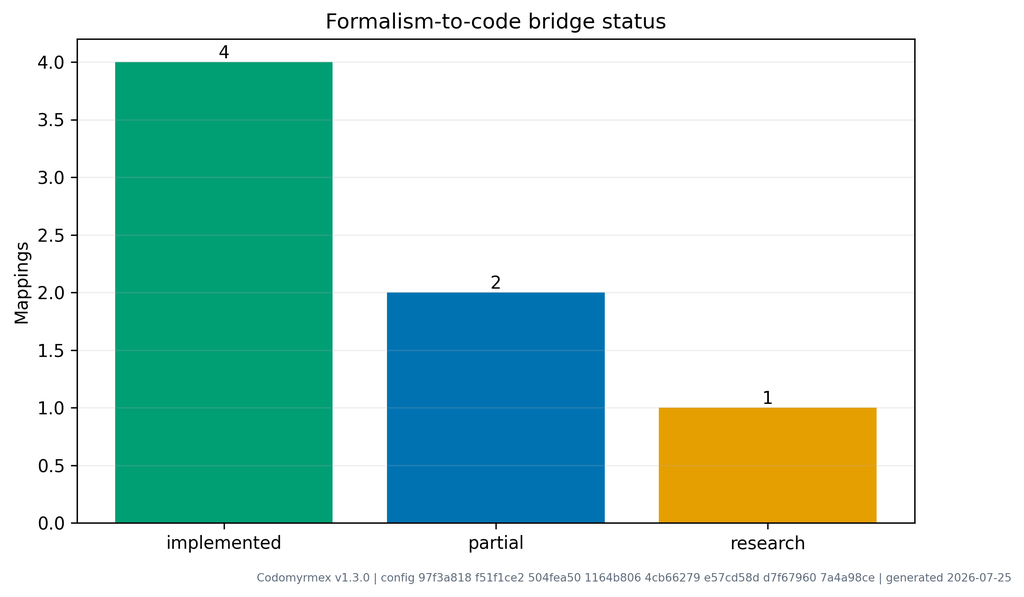

Figure 16: Current formalism-to-code inventory with 7 mappings: 4 implemented and 2 partial, with 1 research. The chart measures documented bridge status and evidence anchors, not theorem coverage or semantic equivalence.

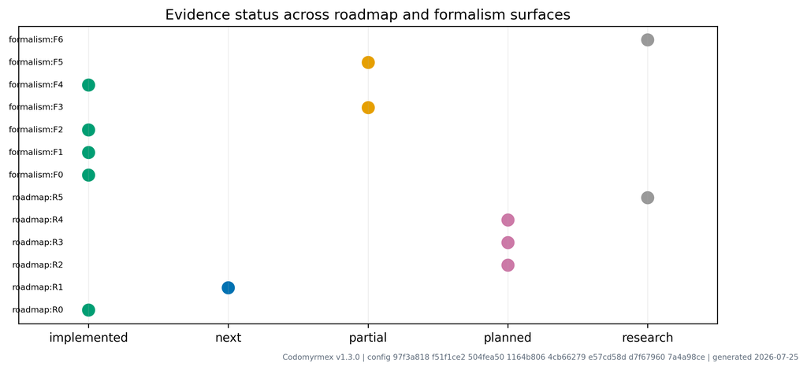

Figure 17: Evidence-status matrix for the configured roadmap and formalism crosswalk. Status labels are generated from the active configuration and indicate what artifacts exist or remain conditional; they are not completion guarantees or measured implementation outcomes.

The visual in Figure 15 shows correspondence as a chain with missing links, not as a proof graph. Green denotes a mapping whose implementation and focused evidence are present; blue denotes a partial bridge; amber and pink denote future work or a research component.

The inventory summary in Figure 16 counts these documented statuses, while Figure 17 places the formalism rows beside the roadmap milestones. Neither visualization measures theorem coverage; both are navigation and claim-boundary aids.

## 11.2 Current correspondence inventory

The configured inventory contains 7 mappings: 4 implemented, 2 partial, and 1 research. The first table records the formal layer and its current status; the second records the translation and evidence boundary. Both tables are generated from `docs/manuscript/config.yaml` and validated against the current repository paths before rendering.

Formalism inventory and implementation status. {#tbl:formalism-code-inventory}

| ID | Mapping | Formal layer | Formal object | Status |
| --- | --- | --- | --- | --- |
| F0 | **Typed operational semantics** | State-transition contract | Proposal, verdict, reported consequence, and kernel state transition | Implemented |
| F1 | **Discrete dynamical recurrence** | Bounded state recurrence | s_(t+1)=max(0, s_t-epsilon) for a trace without new deposits | Implemented |
| F2 | **Piecewise decision semantics** | Rule system with hard overrides | Weighted score, hazard tiers, and EXECUTE/HOLD/REFUSE precedence | Implemented |
| F3 | **Runtime invariant predicates** | Executable design-by-contract checks | Bounds, monotone role thresholds, enum separation, and gate-weight conservation | Partial |
| F4 | **Structural code-change verification** | AST-preservation rules | No deletion of public functions, no removed parameters, and order-compatible signatures | Implemented |
| F5 | **SMT invariant proving** | Satisfiability-based proof obligation | C AND not(invariant) is unsatisfiable | Partial |
| F6 | **Probabilistic and Active Inference models** | Generative model, posterior, and policy evaluation | p(o,s), q(s), transition/observation models, preferences, and expected free energy | Research |

Translation, evidence, and claim boundaries for the formalism inventory. {#tbl:formalism-code-evidence}

[output not shown]

Table **¿tbl:formalism-code-inventory?** is the status view; Table **¿tbl:formalism-code-evidence?** is the evidence and limitation view. Keeping both views explicit prevents a green implementation row from being read as a universal proof.

The inventory distinguishes *representation* from *verification*. For example, `ActiveInferenceAgent` and `InferenceEngine` provide probabilistic components, but their presence does not connect them to the Colony Kernel’s deterministic gate. Conversely, the gate recurrence and the AST-preservation rules have executable bridges but do not imply that the resulting policy is safe or optimal.

## 11.3 How the formalisms compose

The useful relationship among the layers is a sequence of constrained translations:

**Operational semantics → recurrence.** Typed `ColonySignal`, `ActionProposal`, and `GateResult` objects define the state vocabulary. `PheromoneStore` then supplies a discrete transition for one part of that state. The recurrence is a projection of the operational state, not a complete semantics for the kernel.

**Recurrence → decision rule.** The gate observes the projected local field and applies a piecewise risk function plus hard overrides. Monotonicity of the recurrence or risk function can be proved arithmetically while the composition, ordering, and side effects still require integration tests.

**Decision rule → invariant predicate.** Bounds, threshold ordering, and weight conservation can be stated as executable predicates. These predicates should import the same runtime constants as the decision rule; copied constants create a second model that can pass while the implementation changes.

**Invariant predicate → symbolic obligation.** An SMT bridge can prove a supplied obligation such as $C\land\neg I$ being unsatisfiable. It proves the encoded obligation, not the Python implementation, unless a sound state-to-symbol translation and a correspondence theorem are supplied. The repository now includes a kernel-specific, bounded encoding and a structured `unavailable` result when optional Z3 is absent; the encoding remains evidence about the stated obligations, not a whole-program proof.

**Deterministic state → probabilistic model.** A probabilistic or Active-Inference model must introduce random variables, likelihoods, priors, transition dynamics, preferences, and an observation protocol. Deterministic pressure, trust, or gate scores may be observations or interface projections, but they are not posteriors or expected free energy without those definitions.

These relations are directional. A code path can instantiate a formal recurrence, while an equation cannot by itself establish that a caller, scheduler, or persistence layer actually follows the equation. The crosswalk therefore treats implementation evidence as necessary for a code claim and formal definitions as necessary for a mathematical claim; neither substitutes for the other.

## 11.4 Integration research agenda

The next work is deliberately staged so that each stronger connection depends on a weaker one being replayable:

1. **State and trace schema.** The versioned ledger and replay schema now link proposal digest, gate verdict, execution authorization, execution receipt, outcome evidence, and actor. Focused tests cover replay, omission, duplication, nonce reuse, and unauthorized relinking; outcomes are not promoted to inference data automatically.
2. **Kernel-specific invariant encoding.** A solver-neutral contract and optional Z3 backend now return proved, refuted, unknown, timeout, or unavailable states. The remaining research task is a broader correspondence audit across generated states.
3. **Refinement tests.** The independent reference interpreter and differential tests cover the current gate projection. More transition families should be added before claiming complete refinement.
4. **Probabilistic adapter.** The explicit adapter declares an observation model over attested traces, a latent state space, priors, transition and observation models, preferences, and policy horizon. Keep the deterministic gate as a baseline and report calibration, held-out log loss, utility, refusal cost, and compute cost.
5. **Cross-formalism evidence bundle.** Publish the source commit, configuration and environment digests, seeds, inputs, raw traces, solver versions, generated tables and figures, and all negative or inconclusive results. Promotion requires the evidence bundle and the stated falsifier, not a plausible narrative.

The Section 10 milestones are the release-level plan; this section is the translation method that makes a milestone’s formal and executable parts composable. A future positive result may justify a stronger claim only after the relevant bridge is implemented, independently replayed, and shown not to collapse into a test of the same labels it is intended to validate.

## 11.5 Scope and non-equivalence

The current release establishes several local correspondences and exposes their gaps. It does not provide a formal semantics for all modules, a proof-carrying build, a complete refinement proof from Python to SMT, a causal model of outcomes, or an integrated Active Inference controller. The appropriate scholarly claim is therefore methodological: Codomyrmex provides a substrate in which formal objects, code anchors, tests, and claim boundaries can be recorded together. Whether those connections produce better safety, utility, calibration, or generalization remains an empirical question.

# 12 Appendix: Design Rationale, Assumptions, and Alternatives

This appendix records why the released Colony Kernel uses its present mechanisms and what each choice gives up. The decisions are engineering choices, not proofs that the selected policy is optimal. Where an alternative would require outcome data, the release treats calibration as future evaluation rather than retroactively presenting a hand-set constant as an empirical result.

The numeric values shown here are current implementation defaults or illustrative initial settings, not universal constants, fitted parameters, or empirical estimates. They are configurable and can be tuned or replaced through the corresponding runtime policy, configuration, or presentation inputs; after a change, regenerate the tests, tables, figures, and manuscript before interpreting the result. The appendix consequently distinguishes runtime defaults, presentation settings, and future-study inputs wherever their roles differ.

## 12.1 DR-1: Weighted additive gate with hard overrides

After its early-return checks, `ActuationGate` computes the score in Equation 23:

$$g=0.3b+0.3h
+0.25t+0.15c,
\qquad{(23)}$$

where $b$ is budget credit, $h$ is local hazard credit derived from the larger of RISK and FAILURE pressure, $t$ is tiered trust credit, and $c$ is proposal completeness. The score is a routing policy, not a probability of safety or harm.

Table **¿tbl:gate-formula-tradeoffs?** summarizes the relevant alternatives.

Tradeoffs among candidate ordinary-score policies. {#tbl:gate-formula-tradeoffs}

| Policy family | Useful property | Cost or missing prerequisite |
| --- | --- | --- |
| Weighted additive | Direct component decomposition; partial credit supports HOLD | Compensation among components; hand-set weights require external calibration |
| Multiplicative | A zero component can dominate without a separate rule | Small components suppress the whole score; interpretation depends on scaling |
| Explicit rule set | Named conditions are easy to audit | Interactions and ordering grow with the rule set |
| Learned scorer | Can estimate interactions from labeled outcomes | Requires representative, independently attested training and calibration data |

The implementation does not rely on the weighted sum for every condition. Missing budget in the integrated path, SANDBOX status, trust below 0.3, and CRITICAL findings take explicit branches. This hybrid keeps the ordinary score inspectable while reserving non-compensatory treatment for named conditions. It also means that analysis of the formula alone is insufficient to predict every gate result.

## 12.2 DR-2: Subtractive, tick-driven signal expiry

Each trace stores an evaporation amount $\epsilon$ when deposited. A passive tick uses

$$s_{n+1}=\max(0.0,s_n-\epsilon),
\qquad{(24)}$$

and removes a trace at zero. At the defaults, FAST, NORMAL, and SLOW subtract 0.3, 0.1, and 0.02 per tick. Equation 24 is exact for a trace with no new deposit, reinforcement, or read-side effect.

The choice makes expiry finite and contract tests easy to replay. Its tradeoffs are equally explicit: ticks are logical rather than wall-clock time, a larger effective deposit lasts longer, and repeated deposits can dominate the nominal class. Source and trust multipliers affect initial strength, while the field cap bounds accumulated strength. Deployments that need real-time semantics must define the scheduler-to-tick mapping rather than reinterpret a tick as an undocumented number of seconds.

## 12.3 DR-3: Process-local state with optional file-backed consequences

This design minimizes setup and keeps real SQLite behavior available to tests. It does not provide shared multi-process state, restart recovery for signal pressure, remote replication, migration management, or conflict resolution. A deployment requiring those properties needs an explicit state architecture; changing only the consequence database path is not sufficient.

## 12.4 DR-4: Clipped additive trust updates

The integrated outcome path applies fixed deltas and clips trust to $[0.0,1.0]$. A clean reported outcome adds 0.04; a failed one changes trust by -0.08; repair and human-feedback terms can change the net update. The rule is transparent and supports exact fixtures such as Table **¿tbl:trust_trajectory?**.

The cost of that simplicity is that trust is neither a calibrated posterior nor an uncertainty interval. Equal scores can arise from different histories, and constant-step updates do not imply convergence to a unique equilibrium. More importantly, current outcomes are caller supplied: the MCP surface does not consume a durable prior EXECUTE record. Before trust is used in an adversarial setting, proposal, execution, outcome, and attestation must be linked.

## 12.5 DR-5: Three routing outcomes

EXECUTE, HOLD, and REFUSE distinguish three operational states:

- EXECUTE returns an advisory approval verdict to the caller;
- HOLD requests revision, evidence, budget recovery, or later reevaluation; and
- REFUSE rejects the proposal and, in the integrated path, deposits FAILURE pressure.

HOLD is useful only when revision can change a relevant input at acceptable cost. The release therefore does not claim that a three-way gate universally dominates a binary one. A benchmark must measure revision cost, delay, eventual decision, throughput, and outcome quality. The integrated and standalone budget paths also differ: an integrated budget failure yields HOLD, while the standalone gate with its own ledger returns REFUSE. Callers must choose the intended API rather than assume the labels are interchangeable.

## 12.6 DR-6: Deterministic falsification before scoring

The integrated proposal path runs deterministic checks before gate scoring. The checks cover 10 canonical `AttackVector` categories through 11 check functions. This order makes findings available to the gate and makes the same input replayable without an LLM call.

Deterministic heuristics have bounded, inspectable behavior, but they detect only the patterns they implement. The current checks top out at HIGH severity; CRITICAL remains an input class that would trigger the hard override. A clean report is not proof that a proposal is safe, and returning REFUSE does not physically prevent a separate caller from bypassing the kernel. Stronger deployments need an execution boundary that requires a consumed gate authorization, plus external isolation and monitoring.

## 12.7 DR-7: Role labels separated from action-type policy

The trust-score path maps profiles onto 5 labels: SANDBOX, REPAIR_ANT, MEMORY_ANT, DISPATCHER, and GUARD_ANT. The labels provide a readable lifecycle summary, and SANDBOX is an actual early gate refusal. The other four labels do not currently enforce distinct action-type matrices in `ActuationGate`.

This separation is important. A label taxonomy is inexpensive and auditable, but it is not a complete access-control system. The default lifecycle also has a bootstrap gap: new profiles begin in SANDBOX, the gate refuses their proposals, and trust rises only through submitted outcomes. An external study must either supply a fixed supervised calibration history or implement a narrowly constrained, attested SANDBOX path.

## 12.8 DR-8: Shared location field rather than peer messaging

The pheromone field lets later proposals query pressure by location and signal type without reconstructing every prior consequence record. It supports the paper’s bounded locality claim: a failure at one target can affect that target while an unrelated target remains unchanged.

The current implementation is a central in-process store, not a distributed stigmergic network. The release makes no asymptotic communication claim because actual cost depends on index structure, query pattern, agent topology, and synchronization design. A shared field reduces the API needed for the tested single-process case; it also creates a single-process state boundary and supplies no cross-host consistency protocol.

## 12.9 DR-9: Advisory pruning with a separate destructive API

`PruningDaemon.report()` and the MCP `colony_pruning_report` surface candidates; they do not move files. `PruningDaemon.archive(candidate, dry_run=True)` is also non-mutating by default. A direct caller can pass `dry_run=False`, in which case the implementation moves an existing in-repository path under `docs/plans/archived/` after a containment check.

Keeping discovery separate from mutation makes review possible and prevents the MCP report tool from silently archiving code. The tradeoff is procedural: safety depends on which callers can invoke the lower-level archive method and on reviewing false-positive candidates. Confidence scores are heuristic rankings, not calibrated probabilities, and DEPENDENCY pressure is a veto signal only within the implemented scan rules.

## 12.10 Generated figure inventory

Generated figure registry and evidence class. {#tbl:appendix-figures}

| Asset and evidence class | Intended reading and explicit limit |
| --- | --- |
| `cover.png` — conceptual cover | Visual identity and subsystem motif; no quantitative evidence. |
| `subsystem_architecture.png` — architecture | Kernel ownership of 7 operational components; no latency or distributed-topology claim. |
| `colony_pressure_loop.png` — dependency diagram | Proposal, decision, report, and later-state dependencies; not a literal call trace or autonomous execution. |
| `pheromone_decay.png` — formula-derived | Passive unit-trace paths; not empirical frequency or wall-clock half-life. |
| `gate_score_heatmap.png` — formula-derived | Policy bands over trust and effective hazard; not an observed distribution or calibrated risk. |
| `gate_score_3d.png` — formula-derived | Score envelope over trust and completeness; runtime inputs remain discrete. |
| `trust_trajectory.png` — deterministic fixture | Fixed clean-report updates and label thresholds; not autonomous learning or convergence. |
| `falsification_vectors.png` — code taxonomy | Implemented categories and representative severities; not prevalence, recall, or effectiveness. |
| `fep_correspondence.png` — conceptual analogy | Vocabulary crosswalk; not Bayesian inference, EFE optimization, or formal equivalence. |

Every generator reads the manuscript variable snapshot and stamps a version, compact configuration digest, and generation date. As explained in Section 8, that footer identifies the manuscript configuration used by the figure route; it does not hash all source or authenticate the image. The generated `figure_registry.json` adds an evidence-class label, byte size, and full SHA-256 for each PNG file; it is an integrity inventory for the emitted files, not an external signature.

## 12.11 Calibration and replacement criteria

The gate weights and thresholds were selected as design constants. Replacing them with new hand-set values would change policy, not add evidence. A defensible calibration study should provide representative proposals, consumed execution records, independently attested outcomes, costs of HOLD/revision, pre-registered metrics, held-out evaluation, and calibration diagnostics. A learned policy should remain subordinate to named hard conditions unless the study separately justifies changing those conditions.

The same replacement discipline applies to every decision in this appendix. A real-time field should be judged against replayability and scheduler failures; a durable state backend against migration and recovery tests; role-specific action policies against an explicit matrix; and automated pruning against measured false-positive costs. The present design is valuable because its boundaries are testable—not because it is the final design for every deployment.

## 12.12 Summary

The released design favors small deterministic mechanisms with inspectable inputs and explicit limitations. That choice enables the paired locality result and exact policy figures reported in Section 5. It does not establish external effectiveness, adversarial integrity, restart continuity, or optimal calibration. Those claims require the additional evidence package specified in Table **¿tbl:external-evidence?**.

# Acknowledgements

We thank Marek Pawel Bargiel for conceptual comments on pressure-aware gating / colony-control framing.

# References

AI, LangChain. 2024. “LangGraph: Build Stateful, Multi-Actor Applications with LLMs.” https://github.com/langchain-ai/langgraph.

Alshiekh, Mohammed, Roderick Bloem, Ruediger Ehlers, Bettina Konighofer, Scott Niekum, and Ufuk Topcu. 2018. “Safe Reinforcement Learning via Shielding.” In *Proceedings of the AAAI Conference on Artificial Intelligence*. Vol. 32. https://doi.org/10.1609/aaai.v32i1.11797.

Anthropic. 2024. “Model Context Protocol: An Open Standard for Connecting AI Assistants to the Systems Where Data Lives.” Anthropic. https://modelcontextprotocol.io.

Apt, Krzysztof R. 2003. *Principles of Constraint Programming*. Cambridge: Cambridge University Press.

Bonabeau, Eric, Marco Dorigo, and Guy Theraulaz. 1999. *Swarm Intelligence: From Natural to Artificial Systems*. New York: Oxford University Press.

Buhl, Marie Davidsen, Gaurav Sett, Leonie Koessler, Jonas Schuett, and Markus Anderljung. 2024. “Safety Cases for Frontier AI.” *arXiv Preprint arXiv:2410.21572*. https://arxiv.org/abs/2410.21572.

Debenedetti, Edoardo, Jie Zhang, Mislav Balunovic, Luca Beurer-Kellner, Marc Fischer, and Florian Tramer. 2024. “AgentDojo: A Dynamic Environment to Evaluate Prompt Injection Attacks and Defenses for LLM Agents.” In *Advances in Neural Information Processing Systems, Datasets and Benchmarks Track*. https://arxiv.org/abs/2406.13352.

Dorigo, Marco, and Thomas Stützle. 2004. *Ant Colony Optimization*. Cambridge, MA: MIT Press.

Dwork, Cynthia, and Aaron Roth. 2014. *The Algorithmic Foundations of Differential Privacy*. Vol. 9. 3–4. Now Publishers.

Friston, Karl. 2010. “The Free-Energy Principle: A Unified Brain Theory?” *Nature Reviews Neuroscience* 11 (2): 127–38. https://doi.org/10.1038/nrn2787.

Friston, Karl, Thomas FitzGerald, Francesco Rigoli, Philipp Schwartenbeck, and Giovanni Pezzulo. 2017. “Active Inference: A Process Theory.” *Neural Computation* 29 (1): 1–49. https://doi.org/10.1162/NECO_a_00912.

Grassé, Pierre-Paul. 1959. “La Reconstruction Du Nid Et Les Coordinations Inter-Individuelles Chez Bellicositermes natalensis Et Cubitermes Sp. La Théorie de La Stigmergie: Essai d’interprétation Du Comportement Des Termites Constructeurs.” *Insectes Sociaux* 6 (1): 41–80. https://doi.org/10.1007/BF02223791.

Greshake, Kai, Sahar Abdelnabi, Shailesh Mishra, Christoph Endres, Thorsten Holz, and Mario Fritz. 2023. “Not What You’ve Signed up for: Compromising Real-World LLM-Integrated Applications with Indirect Prompt Injection.” *arXiv Preprint arXiv:2302.12173*. https://arxiv.org/abs/2302.12173.

Huynh, Trung Dong, Nicholas R. Jennings, and Nigel Shadbolt. 2006. “An Integrated Trust and Reputation Model for Open Multi-Agent Systems.” *Autonomous Agents and Multi-Agent Systems* 13 (2): 119–54. https://doi.org/10.1007/s10458-005-6825-4.

Inc., CrewAI. 2024. “CrewAI: Framework for Orchestrating Role-Playing, Autonomous AI Agents.” https://github.com/crewAIInc/crewAI.

Kamvar, Sepandar D., Mario T. Schlosser, and Hector Garcia-Molina. 2003. “The EigenTrust Algorithm for Reputation Management in P2P Networks.” *Proceedings of the 12th International Conference on World Wide Web*, 640–51. https://doi.org/10.1145/775152.775242.

Karpas, Ehud, Omri Abend, Yonatan Belinkov, Barak Lenz, Opher Lieber, Nir Ratner, Yoav Shoham, et al. 2022. “MRKL Systems: A Modular, Neuro-Symbolic Architecture That Combines Large Language Models, External Knowledge Sources and Discrete Reasoning.” *arXiv Preprint arXiv:2205.00445*. https://arxiv.org/abs/2205.00445.

Liu, Xiao, Hao Yu, Hanchen Zhang, Yifan Xu, Xuanyu Lei, Hanyu Lai, Yu Gu, et al. 2023. “AgentBench: Evaluating LLMs as Agents.” *arXiv Preprint arXiv:2308.03688*. https://arxiv.org/abs/2308.03688.

Marsh, Stephen Paul. 1994. “Formalising Trust as a Computational Concept.” PhD thesis, Stirling, Scotland: University of Stirling.

Miller, Mark S., and Jonathan S. Shapiro. 2003. “Paradigm Regained: Abstraction Mechanisms for Access Control.” Johns Hopkins University.

Mitchell, Margaret, Simone Wu, Andrew Zaldivar, Parker Barnes, Lucy Vasserman, Ben Hutchinson, Elena Spitzer, Inioluwa Deborah Raji, and Timnit Gebru. 2019. “Model Cards for Model Reporting.” In *Proceedings of the Conference on Fairness, Accountability, and Transparency*, 220–29. https://doi.org/10.1145/3287560.3287596.

Nakano, Reiichiro, Jacob Hilton, Suchir Balaji, Jeff Wu, Long Ouyang, Christina Kim, Christopher Hesse, et al. 2021. “WebGPT: Browser-Assisted Question-Answering with Human Feedback.” *arXiv Preprint arXiv:2112.09332*. https://arxiv.org/abs/2112.09332.

Parunak, H. Van Dyke. 1997. “"Go to the Ant": Engineering Principles from Natural Multi-Agent Systems.” In *Annals of Operations Research*, 75:69–101. Springer. https://doi.org/10.1023/A:1018980001403.

Patil, Shishir G., Tianjun Zhang, Xin Wang, and Joseph E. Gonzalez. 2023. “Gorilla: Large Language Model Connected with Massive APIs.” *arXiv Preprint arXiv:2305.15334*. https://arxiv.org/abs/2305.15334.

Pearl, Judea. 1988. *Probabilistic Reasoning in Intelligent Systems*. San Francisco: Morgan Kaufmann.

Peng, Roger D. 2011. “Reproducible Research in Computational Science.” *Science* 334 (6060): 1226–27. https://doi.org/10.1126/science.1213847.

Popper, Karl R. 1959. *The Logic of Scientific Discovery*. New York: Basic Books.

Qin, Yujia, Shihao Liang, Yining Ye, Kunlun Zhu, Lan Yan, Yaxi Lu, Yankai Lin, et al. 2023. “ToolLLM: Facilitating Large Language Models to Master 16000+ Real-World APIs.” *arXiv Preprint arXiv:2307.16789*. https://arxiv.org/abs/2307.16789.

Raji, Inioluwa Deborah, Andrew Smart, Rebecca N. White, Margaret Mitchell, Timnit Gebru, Ben Hutchinson, Jamila Smith-Loud, Daniel Theron, and Parker Barnes. 2020. “Closing the AI Accountability Gap: Defining an End-to-End Framework for Internal Algorithmic Auditing.” In *Proceedings of the 2020 Conference on Fairness, Accountability, and Transparency*, 33–44. https://doi.org/10.1145/3351095.3372873.

Ramstead, Maxwell J. D., Axel Constant, Paul B. Badcock, and Karl J. Friston. 2019. “Variational Ecology and the Physics of Sentient Systems.” *Physics of Life Reviews* 31: 188–205.

Rose, Scott, Oliver Borchert, Stu Mitchell, and Sean Connelly. 2020. “Zero Trust Architecture.” NIST Special Publication 800-207. National Institute of Standards; Technology. https://doi.org/10.6028/NIST.SP.800-207.

Ruan, Yangjun, Honghua Dong, Andrew Wang, Silviu Pitis, Yongchao Zhou, Jimmy Ba, Yann Dubois, Chris J. Maddison, and Tatsunori Hashimoto. 2023. “Identifying the Risks of LM Agents with an LM-Emulated Sandbox.” *arXiv Preprint arXiv:2309.15817*. https://arxiv.org/abs/2309.15817.

Sabater, Jordi, and Carles Sierra. 2005. “Review on Computational Trust and Reputation Models.” *Artificial Intelligence Review* 24 (1): 33–60. https://doi.org/10.1007/s10462-004-0595-7.

Saltzer, Jerome H., and Michael D. Schroeder. 1975. “The Protection of Information in Computer Systems.” *Proceedings of the IEEE* 63 (9): 1278–308. https://doi.org/10.1109/PROC.1975.9939.

Schick, Timo, Jane Dwivedi-Yu, Roberto Dessì, Roberta Raileanu, Maria Lomeli, Luke Zettlemoyer, Nicola Cancedda, and Thomas Scialom. 2023. “Toolformer: Language Models Can Teach Themselves to Use Tools.” *arXiv Preprint arXiv:2302.04761*. https://arxiv.org/abs/2302.04761.

Seto, David, Bruce Krogh, Lui Sha, and Alongkrit Chutinan. 1998. “The Simplex Architecture for Safe Online Control System Upgrades.” In *Proceedings of the 1998 American Control Conference*, 3504–8. https://doi.org/10.1109/ACC.1998.703255.

Trivedi, Harsh, Tushar Khot, Mareike Hartmann, Ruskin Manku, Vinty Dong, Edward Li, Shashank Gupta, Ashish Sabharwal, and Niranjan Balasubramanian. 2024. “AppWorld: A Controllable World of Apps and People for Benchmarking Interactive Coding Agents.” In *Proceedings of the 62nd Annual Meeting of the Association for Computational Linguistics*. https://arxiv.org/abs/2407.18901.

Wooldridge, Michael, and Nicholas R. Jennings. 1995. “Intelligent Agents: Theory and Practice.” *The Knowledge Engineering Review* 10 (2): 115–52. https://doi.org/10.1017/S0269888900008122.

Wu, Qingyun, Gagan Bansal, Jieyu Zhang, Yiran Wu, Beibin Li, Erkang Zhu, Li Jiang, et al. 2023. “AutoGen: Enabling Next-Gen LLM Applications via Multi-Agent Conversation.” In *arXiv Preprint arXiv:2308.08155*. https://arxiv.org/abs/2308.08155.

Xie, Tianbao, Danyang Zhang, Jixuan Chen, Xiaochuan Li, Siheng Zhao, Ruisheng Cao, Toh Jing Hua, et al. 2024. “OSWorld: Benchmarking Multimodal Agents for Open-Ended Tasks in Real Computer Environments.” *arXiv Preprint arXiv:2404.07972*. https://arxiv.org/abs/2404.07972.

Yang, John, Carlos E. Jimenez, Alexander Wettig, Kilian Lieret, Shunyu Yao, Karthik Narasimhan, and Ofir Press. 2024a. “SWE-agent: Agent-Computer Interfaces Enable Automated Software Engineering.” In *Advances in Neural Information Processing Systems*. https://arxiv.org/abs/2405.15793.

———. 2024b. “SWE-bench: Can Language Models Resolve Real-World GitHub Issues?” *arXiv Preprint arXiv:2310.06770*. https://arxiv.org/abs/2310.06770.

Yao, Shunyu, Jeffrey Zhao, Dian Yu, Nan Du, Izhak Shafran, Karthik Narasimhan, and Yuan Cao. 2023. “ReAct: Synergizing Reasoning and Acting in Language Models.” In *International Conference on Learning Representations*. https://arxiv.org/abs/2210.03629.

Zhan, Qiusi, Zhixiang Liang, Zifan Ying, and Daniel Kang. 2024. “InjecAgent: Benchmarking Indirect Prompt Injections in Tool-Integrated Large Language Model Agents.” *arXiv Preprint arXiv:2403.02691*. https://arxiv.org/abs/2403.02691.

Zhang, Zhexin, Shiyao Cui, Yida Lu, Jingzhuo Zhou, Junxiao Yang, Hongning Wang, and Minlie Huang. 2024. “Agent-SafetyBench: Evaluating the Safety of LLM Agents.” *arXiv Preprint arXiv:2412.14470*. https://arxiv.org/abs/2412.14470.

Zhou, Shuyan, Frank F. Xu, Hao Zhu, Xuhui Zhou, Robert Lo, Abishek Sridhar, Xianyi Cheng, et al. 2023. “WebArena: A Realistic Web Environment for Building Autonomous Agents.” *arXiv Preprint arXiv:2307.13854*. https://arxiv.org/abs/2307.13854.